# `PYTHON NOTES: V25.01.08`

## `Print() Function:`

```python
print("Hello Pratik")
```

```
Hello Pratik
```

## `Input() Function:`

```python
value = input("Enter a Value: ")
print(value)
```

```
Enter a Value:  23
```

```
23
```

## `Type() Function:`

```python
print(type(24))
type(24)
```

```
<class 'int'>
```

```
int
```

## `Data Types: V25.01.08`

1. `Numeric Data Type`

```python
print("Numeric Data Type")
print(type(23))
print(type(23.5))
print(type(2+2j))
```

```
Numeric Data Type
<class 'int'>
<class 'float'>
<class 'complex'>
```

2. `Sequential Data Type`

```python
print("Sequential Data Type")
print(type([22,22.3,2+2j]))
print(type((22,22.3,2+2j)))
print(type(set("aabbccdd")))
print(type({"name":"Pratik" ,"age":22}))
```

```
Sequential Data Type
<class 'list'>
<class 'tuple'>
<class 'set'>
<class 'dict'>
```

3. `String Data Type`

```python
print("String Data Type")
print(type("Pratik"))
```

[output not shown]

4. `Boolean Data Type`

```python
print("Boolean Data Type")
print(type(True))
```

[output not shown]

## Operators: V25.01.09 - V25.01.10

1. `Assignment Arithmatic Operator`

```python
print("Assignment Arithmatic Operator")
num1 = int(input("Enter 1st Number: "))
num2 = int(input("Enter 2nd Number: "))
num1+=num2
print("Addition of two Number is: ",num1)
num1-=num2
print("Subtraction of two Number is: ",num1)
num1*=num2
print("Multiplication of two Number is: ",num1)
num1/=num2
print("Division of two Number is: ",num1)
num1//=num2
print("Floor Division of two Number is: ",num1)
num1**=num2
print("Power of two Number is: ",num1)
```

```
Assignment Arithmatic Operator
Addition of two Number is:  4
Subtraction of two Number is:  2
Multiplication of two Number is:  4
Division of two Number is:  2.0
Floor Division of two Number is:  1.0
Power of two Number is:  1.0
```

2. `Relational Operator`

```python
print("Relational Operator")
print(num1>=num2)
print(num1<=num2)
print(num1==num2)
print(num1!=num2)
```

[output not shown]

[output not shown]

3. `Logical Operator V25.01.10`

```python
print("Logical Operator")
print(44>=33 and 44>=22)
print(22<=22 or 33<=33)
print(not True)
```

```
Logical Operator
True
True
False
```

4. `Bitwise Operator`

```python
print("Bitwise Operator")
print(bin(15))
print(1 & 1)
print(15 | 11)
print(15 ^ 11)
print(~11)
print(bin(15>>2))
print(bin(15<<2))
print(15>>2)
print(15<<2)
```

[output not shown]

5. `Membership Operator`

```python
print("Membership Operator:")
a = "ABCD"
print("A" in a)
```

```
Membership Operator:
True
```

6. `Identity Operator`

```python
print("Identity Operator:")
a = "ABCD"
b = "ABCD"
print(a is b)
```

```
Identity Operator:
True
```

## `Jupyter Installation: V25.01.13`

## `Control Statement: V25.01.14`

1. `IF Statement`

```python
if True:
    print("Welcome Guys!!")
```

```
Welcome Guys!!
```

```python
if False:
    print("Welcome Guys!!")
    # Blanck!!  Print Nothing.
```

```python
if 1:
    print("Welcome Guys!!")
    # Truth Value
```

```
Welcome Guys!!
```

```python
if 0:
    print("Welcome Guys!!")
    # Blanck!!  Print Nothing. Falsy Value
```

```python
if -0:
    print("Welcome Guys!!")
    # Blanck!!
    # Print Nothing.
    # Falsy Value
    # Entity : Something that exist.
    # -0 : Technicaly Wrong.
```

2. `If-Else Statement`

```python
if True:
    print("Welcome Guys!!")
else:
    print("Bhaag...")
```

```
Welcome Guys!!
```

- `Question:` Accept a no from user and check if it is Even or Odd.

```python
print("Print Even or Odd Numbers.")
num = int(input("Enter a Number: "))
if num%2 == 0 :
    print(num," is a Even Number.")
else:
    print(num," is a Odd Number.")
```

```
Print Even or Odd Numbers.
```

```
Enter a Number:  5
```

```
5  is a Odd Number.
```

- `Question:` Accept a no from user and check if it is divisible by 7 or 13.

```python
print("Check a number divisible by 7 or 13.")
num = int(input("Enter a Number: "))
if num%7 == 0 or num%13 ==0 :
    print(num," is divisible.")
else:
    print(num," is not divisible.")
```

```
Check a number divisible by 7 or 13.
```

```
Enter a Number:  14
```

```
14  is divisible.
```

3. If-Elif Statement | If-Elif Ladder
- `Question:` Accept a no from user and check if it is Greater, Smaller or Equal to 23.

```python
print("Check a Number is Greater, Smaller or Equal.")
num = int(input("Enter a Number: "))
if num>23:
    print(num," is a Greater than 23.")
elif num==23:
    print(num," is a Equal to 23.")
else:
    print(num," is a Smaller than 23.")
```

```
Check a Number is Greater, Smaller or Equal.
```

```
Enter a Number:  23
```

```
23  is a Equal to 23.
```

- `Question:` Accept a Budget from User.

```python
budget = int(input("Enter your Budget: "))
if budget>=300 and budget<=500:
    print("International Trip.")
elif budget>=200 and budget<=299:
    print("National Trip.")
elif budget>=100 and budget<=199:
    print("City Trip.")
elif budget>=50 and budget<=99:
    print("Local Trip.")
elif budget>=1 and budget<=49:
    print("Gully Trip.")
else:
    print("Undefine Budget.")
```

```
Enter your Budget:  1
```

```
Gully Trip.
```

- `Question:` Accept a Designation from User and print is they apply for senior Position.

```python
designation = input("Enter what Designationyou are Applying? Manager or Executive")
if "Manager" == designation:
    senior = input("Are you  applying for Senior Position? Yes or No:")
    if "yes" == senior:
        print("2Lakh Sallary.")
    else:
        print("1Lakh Sallary.")
elif "Executive" == designation:
    senior = input("Are you applying for Senior Position? Yes or No:")
    if "yes" == senior:
        print("70K Sallary.")
    else:
        print("25K Sallary.")
else:
    print("Undefined Designation.")
```

```
25K Sallary.
```

4. `Match Case`

```python
value = 3
match value:
    case 1:
        print("Label 1")
    case 2:
        print("Label 2")
    case 3:
        print("Label 3")
    case _:
        print("Default Case ")
```

```
Label 3
```

## `Loops: V25.01.15`

### `For Loop - Repetition`

```python
for i in range(1,10):
    print(i)
```

```
1
2
3
4
5
6
7
8
9
```

```python
for i in range(11):
    print(i)
```

```
0
1
2
3
4
5
6
7
8
9
10
```

```python
for i in range(1,11):
    print(i)
```

```
1
2
3
4
5
6
7
8
9
10
```

```python
for i in range(1,11):
    print(i, end=" ")
```

```
1 2 3 4 5 6 7 8 9 10
```

```python
for i in range(20,41):
    print(i, end=" ")
```

```
20 21 22 23 24 25 26 27 28 29 30 31 32 33 34 35 36 37 38 39 40
```

- `Question: Print Even Numbers 1 to 100`

```python
for i in range(1,101):
    if i%2==0:
        print(i, end=" ")
```

```
2 4 6 8 10 12 14 16 18 20 22 24 26 28 30 32 34 36 38 40 42 44 46 48 50 52 54 56 58 60 62 64 66 68 70 72 74 76 78 80 82 84 86 88 90 92 94 96 98 100
```

- `Question: Display Number Divisible by 2 & 5 from 1 to 100.`

```python
for i in range(1, 101):
    if i%2==0 and i%5==0:
        print(i, end=" ")c
```

```
10 20 30 40 50 60 70 80 90 100
```

- `Question: Display Number Divisible by 13,17 from 1 to 100.`

```python
for i in range(1, 101):
    if i%13==0 and i%17==0:
        print(i, end=" ")c
```

[output not shown]

- `Patterns:`
- `Square Row Number Patterns:`
- `11111`
- `22222`
- `33333`
- `44444`
- `55555`

```python
for i in range(1,6):
    for j in range(1,6):
        print(i, end=" ")
    print("")
```

```
1 1 1 1 1
2 2 2 2 2
3 3 3 3 3
4 4 4 4 4
5 5 5 5 5
```

- `Square Column Number Patterns:`
- `12345`
- `12345`
- `12345`
- `12345`
- `12345`

```python
for i in range(1,6):
    for j in range(1,6):
        print(j, end=" ")
    print("")
```

```
1 2 3 4 5
1 2 3 4 5
1 2 3 4 5
1 2 3 4 5
1 2 3 4 5
```

- `Right Half Increasing Pyramid Column Number Patterns:`
- `1`
- `12`
- `123`
- `1234`
- `12345`

```python
for i in range(1,6):
    for j in range(1,6):
        if i>=j:
            print(j, end=" ")
    print("")
```

```
1
1 2
1 2 3
1 2 3 4
1 2 3 4 5
```

```python
for i in range(1, 6):
    for j in range(1, 6):
        print(j, end=" ")
    print("")
```

```
1 2 3 4 5
1 2 3 4 5
1 2 3 4 5
1 2 3 4 5
1 2 3 4 5
```

- `Decreasing Pyramid Patterns:`
- `12345`
- `2345`
- `345`
- `45`
- `5`

```python
for i in range(1,6):
    for j in range(1,6):
        if i<=j:
            print(j, end=" ")
    print("")
```

```
1 2 3 4 5
2 3 4 5
3 4 5
4 5
5
```

- `Star Square Patterns:`
- `* * * * *`
- `* * * * *`
- `* * * * *`
- `* * * * *`
- `* * * * *`

```python
for i in range(1,6):
    for j in range(1,6):
        print("*", end=" ")
    print("")
```

- `Right Half Pyramid Patterns:`
- `*`
- `* *`
- `* * *`
- `* * * *`
- `* * * * *`

```python
for i in range(1,6):
    for j in range(1,6):
        if i>=j:
            print("*", end=" ")
    print("")
```

```python
for i in range(6):
    for j in range(i):
        print("*",end=" ")
    print()
```

- `Left Half Pyramid Patterns:`
- `* * * * *`
- `* * * *`
- `* * *`
- `* *`
- `*`

```python
for i in range(1,6):
    for j in range(1,6):
        if i<=j:
            print("*", end=" ")
    print("")
```

```python
for i in range(5):
    for j in range(5-i):
        print("*",end=" ")
    print()
```

- `Space & Half Pyrmid Pattern` `V25.01.26`
- `*`
- `**`
- `***`
- `****`
- `*****`

```python
for i in range(1,6):
    for j in range(5,0,-1):
        if j>=i:
            print(" ",end="")
    for k in range(1,6):
        if k<=i:
            print("*",end="")
    print("")
```

- `Space & Half Pyrmid Pattern`
- `*****`
- `****`
- `***`
- `**`
- `*`

```python
for i in range(1,6):
    for j in range(1,6):
        if j<=i:
            print(" ",end="")
    for k in range(5,0,-1):
        if k>=i:
            print("*",end="")
    print("")
```

- `Space & Pyramid Pattern`
- `**`
- `****`
- `******`
- `********`
- `**********`

```python
for i in range(1,6):
    for j in range(5,0,-1):
        if j>=i:
            print(" ",end="")
    for k in range(1,6):
        if k<=i:
            print("*",end="")
    for k in range(1,6):
        if k<=i:
            print("*",end="")
    print("")
```

- `Space & Pyramid Pattern`
- `*`
- `***`
- `*****`
- `*******`
- `*********`

```python
for i in range(1,6):
    for j in range(5,0,-1):
        if j>=i:
            print(" ",end="")
    for k in range(1,6):
        if k<=i:
            print("*",end="")
    for k in range(2,6):
        if k<=i:
            print("*",end="")
    print("")
```

- `Space & Pyramid Pattern`
- `**********`
- `********`
- `******`
- `****`
- `**`

```python
for i in range(1,6):
    for j in range(1,6):
        if j<=i:
            print(" ",end="")
    for k in range(5,0,-1):
        if k>=i:
            print("*",end="")
    for k in range(5,0,-1):
        if k>=i:
            print("*",end="")
    print("")
```

- `Space & Pyramid Pattern`
- `*********`
- `*******`
- `*****`
- `***`
- `*`

```python
for i in range(1,6):
    for j in range(1,6):
        if j<=i:
            print(" ",end="")
    for k in range(5,0,-1):
        if k>=i:
            print("*",end="")
    for k in range(4,0,-1):
        if k>=i:
            print("*",end="")
    print("")
```

- `Diamond Pattern`
- `*`
- `***`
- `*****`
- `*******`
- `*********`
- `*********`
- `*******`
- `*****`
- `***`
- `*`

```python
for i in range(1,6):
    for j in range(5,0,-1):
        if j>=i:
            print(" ",end="")
    for k in range(1,6):
        if k<=i:
            print("*",end="")
    for k in range(2,6):
        if k<=i:
            print("*",end="")
    print("")
for i in range(1,5):
    for j in range(0,5):
        if j<=i:
            print(" ",end="")
    for k in range(4,0,-1):
        if k>=i:
            print("*",end="")
    for k in range(3,0,-1):
        if k>=i:
            print("*",end="")
    print("")
```

## `Function: V25.01.20`

- Block of code which executes targeted Logic.

## `Non-paametrise Function`

```python
def Info():
    print("Hello I.T.")
Info()
```

```
Hello I.T.
```

```python
def Name():
    print("Hello Pratik..!")
Info()
```

```
Hello I.T.
```

- `return keyword` : `Returns to Function Call Value.`

```python
def Data():
    a = int(input("Enter a Number: "))
    return a;
Num = Data()
print("Enter Number is: ",Num)
```

```
Enter Number is:  55
```

- `Question: Accept two values from User and return there Addition, Subtraction, Multiplication, Division.`

```python
def add():
    a = int(input("Enter 1'st Number: "))
    b = int(input("Enter 2'nd Number: "))
    return a+b;
result = add()
print("Addition of two Numbers is: ",result)
```

```
Addition of two Numbers is:  10
```

```python
def sub():
    a = int(input("Enter 1'st Number: "))
    b = int(input("Enter 2'nd Number: "))
    return a-b;
result = sub()
print("Subtraction of two Numbers is: ",result)
```

```
Subtraction of two Numbers is:  1
```

```python
def mul():
    a = int(input("Enter 1'st Number: "))
    b = int(input("Enter 2'nd Number: "))
    return a*b;
result = mul()
print("Multiplication of two Numbers is: ",result)
```

```
Multiplication of two Numbers is:  25
```

```python
def div():
    a = int(input("Enter 1'st Number: "))
    b = int(input("Enter 2'nd Number: "))
    return a/b;
result = div()
print("Division of two Numbers is: ",result)
```

```
Division of two Numbers is:  1.0
```

```python
def mod():
    a = int(input("Enter 1'st Number: "))
    b = int(input("Enter 2'nd Number: "))
    return a%b;
result = mod()
print("Modulos of two Numbers is: ",result)
```

```
Modulos of two Numbers is:  0
```

```python
def expo():
    a = int(input("Enter 1'st Number: "))
    b = int(input("Enter 2'nd Number: "))
    return a**b;
result = expo()
print("Power of two Numbers is: ",result)
```

```
Power of two Numbers is:  25
```

- `break keyword is part of loop` -> `Terminates the Execution of Code.`

```python
def loop1():
    for i in range(1,11):
        if i == 5:
            break
        else:
            print(i,end=" ")
loop1()
```

```
1 2 3 4
```

- `continue keyword is part of loop` -> `Omits Perticular Situation.`

```python
def loop1():
    for i in range(1,11):
        if i == 5:
            continue
        else:
            print(i,end=" ")
loop1()
```

```
1 2 3 4 6 7 8 9 10
```

```python
def loop1():
    for i in range(1,11):
        if i == 7:
            continue
        else:
            print(i,end=" ")
loop1()
```

```
1 2 3 4 5 6 8 9 10
```

```python
def loop1():
    for i in range(1,11):
        if i == 7:
            print(i,end=" ")
            continue
        else:
            print(i,end=" ")
loop1()
```

```
1 2 3 4 5 6 7 8 9 10
```

```python
def data():
    a = 5
    return a
print(data())
```

```
5
```

```python
def data():
    a = 5
    return a * 5
print(data())
```

```
25
```

```python
def data1():
    a = 5
    return a * 5
def data2():
    a = "Pratik"
    return a
print("Value of Int is:",data1(),"Value of String is:",data2())
# Single Python Code has Mutiple Funtions.
# function name should be Unique.
# Multiple Python Function can be call in single print function.
```

```
Value of Int is: 25 Value of String is: Pratik
```

### `Parametrise Function`

- `Compatible - Same Data Type`
- `No. of Argument should Match with No. of Parameters.`

```python
def add(a,b,c):
    return a+b+c
print("Addition of two Number is",add(12,13,14))
```

```
Addition of two Number is 39
```

```python
def add(a,b,c):
    return a+b+c
# print("Addition of two Number is",add(12,13,14))
def add(a,b,c):
    return a+b+c
print("Addition of two Number is",add(12,13,14))
```

```
Addition of two Number is 39
```

```python
def add(a,b):
    return a+b+c
# print("Addition of two Number is",add(12,13,14))
def add(a,b,c):
    return a+b+c
print("Addition of two Number is",add(12,13,14))
# Processor Executes Closer Function. jo sabse close hoga use execute karega. means here is : def add(a,b,c):
```

```
Addition of two Number is 39
```

```python
def add(a,b):
    print("Block 1")
    return a+b+c
# print("Addition of two Number is",add(12,13,14))
def add(a,b,c):
    print("Block 2")
    return a+b+c
print("Addition of two Number is",add(12,13,14))
# Processor Executes Closer Function. jo sabse close hoga use execute karega. means here is : def add(a,b,c):
```

```
Block 2
Addition of two Number is 39
```

```python
def add(a,b):
    print("Block 1")
    return a+b+c
# print("Addition of two Number is",add(12,13,14))
def add(a,b,c):
    print("Block 2")
    return a+b+c
print("Addition of two Number is",add(12,13))
# Creates Ambiguity : Multiple Functions has same name. Mis-match Function. priority has closest one Function.
# Processor Executes Closer Function. jo sabse close hoga use execute karega. means here is : def add(a,b):
```

```
---------------------------------------------------------------------------
TypeError                                 Traceback (most recent call last)
Cell In[47], line 8
      6     print("Block 2")
      7     return a+b+c
----> 8 print("Addition of two Number is",add(12,13))
      9 # Processor Executes Closer Function. jo sabse close hoga use execute karega. means here is : def add(a,b):

TypeError: add() missing 1 required positional argument: 'c'
```

- `Arithmatic Operatios`

```python
def add(num1,num2):
    return num1+num2;
num1 = int(input("Enter 1'st Number: "))
num2 = int(input("Enter 2nd Number: "))
print("Addition of two Number is ",add(num1,num2))
```

```
Addition of two Number is  25
```

```python
def sub(num1,num2):
    return num1-num2;
num1 = int(input("Enter 1'st Number: "))
num2 = int(input("Enter 2nd Number: "))
print("Subtraction of two Number is ",sub(num1,num2))
```

```
Subtraction of two Number is  -1
```

```python
def mul(num1,num2):
    return num1*num2;
num1 = int(input("Enter 1'st Number: "))
num2 = int(input("Enter 2nd Number: "))
print("Product of two Number is ",sub(num1,num2))
```

[output not shown]

```python
def div(num1,num2):
    return num1/num2;
num1 = int(input("Enter 1'st Number: "))
num2 = int(input("Enter 2nd Number: "))
print("Questiont of two Number is ",div(num1,num2))
```

[output not shown]

```python
def floor(num1,num2):
    return num1//num2;
num1 = int(input("Enter 1'st Number: "))
num2 = int(input("Enter 2nd Number: "))
print("Base Integer value of two Number is ",floor(num1,num2))
```

[output not shown]

```python
def mod(num1,num2):
    return num1%num2;
num1 = int(input("Enter 1'st Number: "))
num2 = int(input("Enter 2nd Number: "))
print("Remainder of two Number is ",mod(num1,num2))
```

```
Remainder of two Number is  0
```

```python
def expo(num1,num2):
    return num1**num2;
num1 = int(input("Enter 1'st Number: "))
num2 = int(input("Enter 2nd Number: "))
print("Power of two Number is ",expo(num1,num2))
```

```
Power of two Number is  125
```

- `Bitwise Operatios`

```python
print("Bitwise Operator")
print(bin(15))
print(1 & 1)
print(15 | 11)
print(15 ^ 11)
print(~11)
print(bin(15>>2))
print(bin(15<<2))
print(15>>2)
print(15<<2)
```

```
Bitwise Operator
0b1111
1
15
4
-12
0b11
0b111100
3
60
```

```python
def aand(num1,num2):
    return num1 & num2;
num1 = int(input("Enter 1'st Number: "))
num2 = int(input("Enter 2nd Number: "))
result = aand(num1,num2)
print("And of two Number is ",result)
```

```
And of two Number is  0
```

```python
def oor(num1,num2):
    return num1 | num2;
num1 = int(input("Enter 1'st Number: "))
num2 = int(input("Enter 2nd Number: "))
result = oor(num1,num2)
print("Or of two Number is ",result)
```

```
Or of two Number is  1
```

```python
def exor(num1,num2):
    return num1 ^ num2;
num1 = int(input("Enter 1'st Number: "))
num2 = int(input("Enter 2nd Number: "))
result = exor(num1,num2)
print("Ex-Or of two Number is ",result)
```

```
Ex-Or of two Number is  3
```

```python
def exor(num1):
    return ~num1;
num1 = int(input("Enter 1'st Number: "))
result = exor(num1)
print("Ex-Or of two Number is ",result)
```

```
Ex-Or of two Number is  -2
```

```python
def lso(num1,num2):
    return num1 << num2;
num1 = int(input("Enter 1'st Number: "))
num2 = int(input("Enter 2nd Number: "))
result = lso(num1,num2)
print("Ex-Or of two Number is ",result)
```

```
Ex-Or of two Number is  60
```

```python
def rso(num1,num2):
    return num1 >> num2;
num1 = int(input("Enter 1'st Number: "))
num2 = int(input("Enter 2nd Number: "))
result = rso(num1,num2)
print("Ex-Or of two Number is ",result)
```

```
Ex-Or of two Number is  3
```

```python
def rso(num1,num2):
    return num1 >> num2;
num1 = int(input("Enter 1'st Number: "))
num2 = int(input("Enter 2nd Number: "))
result = rso(num1,num2)
print(bin(num1))
print("Ex-Or of two Number is ",bin(result))
print("Ex-Or of two Number is ",result)
```

```
0b1111
Ex-Or of two Number is  0b11
Ex-Or of two Number is  3
```

```python
def lso(num1,num2):
    return num1 << num2;
num1 = int(input("Enter 1'st Number: "))
num2 = int(input("Enter 2nd Number: "))
result = lso(num1,num2)
print(bin(num1))
print("Ex-Or of two Number is ",bin(result))
print("Ex-Or of two Number is ",result)
```

```
0b1111
Ex-Or of two Number is  0b111100
Ex-Or of two Number is  60
```

### `OOP's: Object Oriented Programming V25.01.21`

- `Identation`
- `Class`
- `Constructor`
- `Class Constructor`
- `Method`
- `Object`
- `Refrence Variable`
- `Instance Variable`
- `Local Variable`
- `Self keyword`
- `Self parameter`
- `Relation between Object and Class:`
  - `Object is an instance of Class`
  - `Constructor: Use to Intialize the Object.`
  - `Object allocates memory by intiallizing class Constructor`
  - `Object defines the Behaviour of Class`
  - `class is the container of Data members and Method functions.`
  - `class is a Blueprint`
  - `More than one constructor allow in python with diffrent parameters.`
  - `def keyword use to define Constructor.`
  - `By using __init__(self) we create Constructor.`
  - `self parameter is mendatory for constructor and methods.`
  - `Constructor does not require object`

```python
class DataInformation:
    def Data(self):
        print("Python Programming!!")
obj = DataInformation()
obj.Data()
```

```
Python Programming!!
```

```python
class Data:
    def Method1(self):
        print("Method1")
    def Method2(self,num1):
        print("Method2")
        print("num1 is ",num1)
    def Method3(self,num1,num2):
        print("Method3")
        print("num1 is ",num1)
        print("num2 is ",num2)
obj = Data()
obj.Method1()
obj.Method2(21)
obj.Method3(31,41)
```

```
Method1
Method2
num1 is  21
Method3
num1 is  31
num2 is  41
```

```python
a = 1
while(a<11):
    print(a,end=" ")
    a=a+1
```

```
1 2 3 4 5 6 7 8 9 10
```

```python
a = 10
while(a>0):
    print(a,end=" ")
    a=a-1
```

```
10 9 8 7 6 5 4 3 2 1
```

```python
class Iteration:
    def Loop1(self):
        a = 1
        while(a<11):
            print(a,end=" ")
            a = a+1
    print()
    def Loop2(self):
        a = 10
        while(a>0):
            print(a,end=" ")
            a = a-1
obj = Iteration()
obj.Loop1()
print()
obj.Loop2()
```

```
1 2 3 4 5 6 7 8 9 10
10 9 8 7 6 5 4 3 2 1
```

- `Armstrong Number: 153` `A Number whose Summation of Cube of Each Digit is the same Number.`

```python
class Armstrong:
    def Evaluate(self):
        num = int(input("Enter a Number"))
        temp = num
        sum = 0
        while(num>0):
            rem = num % 10
            sum = sum + (rem*rem*rem)
            num = num // 10
        if sum == temp:
            print(sum,"is an Armstrong Number.")
        else:
            print(temp,"is not an Armstrong Number.")
obj = Armstrong()
obj.Evaluate()
```

```
121 is not an Armstrong Number.
```

- `Palindrome Number: 121` `A Number Whose Reverce is the same Number.`

```python
class Palindrome:
    def Evaluate(self):
        num = int(input("Enter a Number: "))
        temp = num
        sum = 0
        while(num>0):
            rem = num % 10
            sum = (sum *10) + rem
            num = num // 10
        if sum == temp:
            print(sum, "is a Palindrom Number.")
        else:
            print(temp, "is not a Palindrome Number.")
obj = Palindrome()
obj.Evaluate()
```

```
232 is a Palindrom Number.
```

- `Factorial Number: 5!` `Consider fact = 1 and multiply with ( i ) till the range is satisfy`

```python
class Factorial:
    def Evaluate(self):
        fact = 1
        num = int(input("Enter a Number: "))
        for i in range(1,num+1):
            fact = fact*i
        print("Factorial of ",num,"is ",fact)
obj = Factorial()
obj.Evaluate()
```

```
Factorial of  5 is  120
```

- `Fibonacci Series: 0 1 1 2 3 5 8` `Addition of Privious two Numbers.`

```python
class Fibonacci:
    def Evaluate(self):
        p1 = 0
        p2 = 1
        num = int(input("Enter the Range: "))
        print(p1,"",p2," ",end="")
        for i in range(2,num):
            p3 = p1 + p2
            print(p3," ",end="")
            p1 = p2
            p2 = p3
obj = Fibonacci()
obj.Evaluate()
```

```
0  1  1  2  3  5  8  13  21  34
```

- `Constructor`

```python
class Data:
    a = 10
    b = 20
    def __init__(self):
        print("Constructor..")
Data()
```

```
Constructor..
```

```
<__main__.Data at 0x271adbdd3d0>
```

```python
class Data:
    num1 = 10
    num2 = 20
    def __init__(self):
        print("Constructor..")
    def Method1(self):
        print("Method1")
    def Method2(self,num1):
        print("Method2")
        print("num1 is: ",num1)
    def Method3(self,num1,num2):
        print("Method3")
        print("num1 is: ",num1)
        print("num2 is: ",num2)
obj = Data()
obj.Method1()
obj.Method2(30)
obj.Method3(40,50)
```

```
Constructor..
Method1
Method2
num1 is:  30
Method3
num1 is:  40
num2 is:  50
```

```python
class Data:
    num1 = 10
    num2 = 20
    def __init__(self):
        print("Constructor..")
    def Method1(self):
        print("Method1")
    def Method2(self,num1):
        print("Method2")
        print("num1 is: ",num1)
    def Method3(self,num1,num2):
        print("Method3")
        print("num1 is: ",self.num1)
        print("num2 is: ",self.num2)
obj = Data()
obj.Method1()
obj.Method2(30)
obj.Method3(40,50)
```

```
Constructor..
Method1
Method2
num1 is:  30
Method3
num1 is:  10
num2 is:  20
```

```python
class Data:
    num1 = 10
    num2 = 20
    def __init__(self):
        print("Constructor..")
    def Method1(self):
        self.Method2(30)
        print("Method_1")
    def Method2(self,num1):
        self.Method3(40,50)
        print("Method_2")
        print("num1 is: ",self.num1)
    def Method3(self,num1,num2):
        print("Method_3")
        print("num1 is: ",self.num1)
        print("num2 is: ",self.num2)
obj = Data()
obj.Method1()
```

```
Constructor..
Method_3
num1 is:  10
num2 is:  20
Method_2
num1 is:  10
Method_1
```

```python
class Data:
    num1 = 10
    num2 = 20
    def __init__(self,num1,num2):
        print("Constructor..")
        print("num1 is: ",num1)
        print("num2 is: ",num2)
    def Method1(self):
        print("Method1")
    def Method2(self,num1):
        print("Method2")
        print("num1 is: ",num1)
    def Method3(self,num1,num2):
        print("Method3")
        print("num1 is: ",self.num1)
        print("num2 is: ",self.num2)
obj = Data(100,200)
obj.Method1()
obj.Method2(30)
obj.Method3(40,50)
```

```
Constructor..
num1 is:  100
num2 is:  200
Method1
Method2
num1 is:  30
Method3
num1 is:  10
num2 is:  20
```

```python
class Data:
    num1 = 10
    num2 = 20
    def __init__(self,num1,num2):
        print("Constructor..")
        print("num1 is: ",self.num1)
        print("num2 is: ",self.num2)
    def Method1(self):
        print("Method1")
    def Method2(self,num1):
        print("Method2")
        print("num1 is: ",num1)
    def Method3(self,num1,num2):
        print("Method3")
        print("num1 is: ",self.num1)
        print("num2 is: ",self.num2)
obj = Data(100,200)
obj.Method1()
obj.Method2(30)
obj.Method3(40,50)
```

```
Constructor..
num1 is:  10
num2 is:  20
Method1
Method2
num1 is:  30
Method3
num1 is:  10
num2 is:  20
```

- `Lambda Function: V25.01.23`

```python
value = lambda a: a+10
print(value(25))
```

```
35
```

```python
a = lambda c,d,e: c*d*e
print(a(5,7,9))
```

```
315
```

- `Nested function (Inner Function):`

```python
def Add(a,b):
    print("Addition is ",(a+b))
    def Sub(a,b):
        print("Subtraction is ",(a-b))
        def Mul(a,b,c):
            print("Multiplication is ",(a*b*c))
            def Div(a,b):
                print("Division is ",(a/b))
            Div(10,5)
        Mul(10,20,30)
    Sub(10,11)
Add(5,7)
```

```
Addition is  12
Subtraction is  -1
Multiplication is  6000
Division is  2.0
```

### `String & It's functions:`

- `isalnum:`

```python
data = "Python12345"
print(data.isalnum())
```

```
True
```

```python
data = "Python 12345"
print(data.isalnum())
```

```
False
```

- `isalpha:`

```python
data = "ABCD"
print(data.isalpha())
```

```
True
```

```python
data = "1ABCD"
print(data.isalpha())
```

```
False
```

- `isupper:`

```python
data = "ABCD"
print(data.isupper())
```

```
True
```

- `islower:`

```python
data = "ABCD"
print(data.islower())
```

```
False
```

```python
data = "pqrs"
print(data.islower())
```

```
True
```

```python
data = "pqrs"
print(data.isupper())
```

```
False
```

- `isdigit:`

```python
data = "1234"
print(data.isdigit())
```

```
True
```

```python
data = "1234 "
print(data.isdigit())
```

```
False
```

```python
data = "1234A"
print(data.isdigit())
```

```
False
```

- `Concatination:`

```python
a = "hi,"
b = " How are you?"
result = a+b
print(result)
```

```
hi, How are you?
```

```python
a = "hi,"
b = "How are you?"
result = a+" "+b
print(result)
```

```
hi, How are you?
```

- `join:`

```python
s1 = " sad "
s2 = "Happy"
result = s1.join(s2)
print(result)
```

```
H sad a sad p sad p sad y
```

```python
s1 = "sad"
s2 = " Happy "
result = s2.join(s1)
print(result)
```

```
s Happy a Happy d
```

- `lower:`

```python
s3 = "HAPPY"
print(s3.lower())
```

```
happy
```

- `upper:`

```python
s3 = "happy"
print(s3.upper())
```

```
HAPPY
```

```python
s3 = "AbCd"
print(s3.upper())
```

```
ABCD
```

```python
s3 = "AbCd"
print(s3.lower())
```

```
abcd
```

- `swapcase:`

```python
s3 = "AbCd"
print(s3.swapcase())
```

```
aBcD
```

- `title:`

```python
s3 = "coading is cool when you understand it."
print(s3.title())
```

```
Coading Is Cool When You Understand It.
```

- `Format Specifier:`

```python
id = 731
name = "Pandu"
percentage = 73.9
print("Id is %d, name is %s, Percentage are %f"%(id,name,percentage))
```

```
Id is 731, name is Pandu, Percentage are 73.900000
```

```python
id = 731
name = "Pandu"
percentage = 73.9
print("Id is %d, name is %s, Percentage are %f"%(name,id,percentage))
```

```
---------------------------------------------------------------------------
TypeError                                 Traceback (most recent call last)
Cell In[45], line 4
      2 name = "Pandu"
      3 percentage = 73.9
----> 4 print("Id is %d, name is %s, Percentage are %f"%(name,id,percentage))

TypeError: %d format: a real number is required, not str
```

```python
rollno = 731
name = "Pratik"
percentage = 80.0
print("Roll No is %d, Name is %s, Percentage are %f"%(rollno,name,percentage))
```

```
Roll No is 731, Name is Pratik, Percentage are 80.000000
```

- `replace:`

```python
s3 = "Pandu is a bad boy."
print(s3.replace("bad","good"))
```

```
Pandu is a good boy.
```

- `find:`

```python
s3 = "abcdefgh"
print(s3.find("b"))
```

```
1
```

```python
s3 = "abcdefgh"
print(s3.find("abc"))
```

```
0
```

```python
s3 = "abcdefgh"
print(s3.find("z"))
```

```
-1
```

- `index:`

```python
s3 = "abcdefgh"
print(s3.index("c"))
```

```
2
```

```python
s3 = "abcdefgh"
print(s3.index("z"))
```

```
---------------------------------------------------------------------------
ValueError                                Traceback (most recent call last)
Cell In[58], line 2
      1 s3 = "abcdefgh"
----> 2 print(s3.index("z"))

ValueError: substring not found
```

## `List: V25.01.24`

- `append: Add the element at the end of the list.`

```python
# append element: full element add
a = [22,23,"Python",4+9j]
a.append("hello")
print(a)
```

[output not shown]

```python
# append list into the another list:
a = [22,23,"Python",4+9j]
a.append("hello")
print(a)
b = [22,23,"Python",4+9j]
a.append(b)
print(a)
```

```
[22, 23, 'Python', (4+9j), 'hello']
[22, 23, 'Python', (4+9j), 'hello', [22, 23, 'Python', (4+9j)]]
```

```python
# append tuple into the list:
a = [22,23,"Python",4+9j]
a.append("hello")
print(a)
b = [22,23,"Python",4+9j]
a.append(b)
print(a)
c = (11,22,33,44)
a.append(c)
print(a)
```

```
[22, 23, 'Python', (4+9j), 'hello']
[22, 23, 'Python', (4+9j), 'hello', [22, 23, 'Python', (4+9j)]]
[22, 23, 'Python', (4+9j), 'hello', [22, 23, 'Python', (4+9j)], (11, 22, 33, 44)]
```

- `extend: merge new iteration into the current list.`

```python
# extend list: means mearge with exissting list:
a = [22,23,"Python",4+9j]
a.append("hello")
print(a)
b = [22,23,"Python",4+9j]
a.append(b)
print(a)
c = (11,22,33,44)
a.append(c)
print(a)
d2 = ["happy", "sad","nuteral"]
a.extend(d2)
print(a)
```

```
[22, 23, 'Python', (4+9j), 'hello']
[22, 23, 'Python', (4+9j), 'hello', [22, 23, 'Python', (4+9j)]]
[22, 23, 'Python', (4+9j), 'hello', [22, 23, 'Python', (4+9j)], (11, 22, 33, 44)]
[22, 23, 'Python', (4+9j), 'hello', [22, 23, 'Python', (4+9j)], (11, 22, 33, 44), 'happy', 'sad', 'nuteral']
```

```python
# extend with tuple:
a = [22,23,"Python",4+9j]
a.append("hello")
print(a)
b = [22,23,"Python",4+9j]
a.append(b)
print(a)
c = (11,22,33,44)
a.append(c)
print(a)
d2 = ["happy", "sad","nuteral"]
a.extend(d2)
print(a)
d3 = (55,66,77,88)
a.extend(d3)
print(a)
```

```
[22, 23, 'Python', (4+9j), 'hello']
[22, 23, 'Python', (4+9j), 'hello', [22, 23, 'Python', (4+9j)]]
[22, 23, 'Python', (4+9j), 'hello', [22, 23, 'Python', (4+9j)], (11, 22, 33, 44)]
[22, 23, 'Python', (4+9j), 'hello', [22, 23, 'Python', (4+9j)], (11, 22, 33, 44), 'happy', 'sad', 'nuteral']
[22, 23, 'Python', (4+9j), 'hello', [22, 23, 'Python', (4+9j)], (11, 22, 33, 44), 'happy', 'sad', 'nuteral', 55, 66, 77, 88]
```

```python
# extend element: one by one single charecter in the element added in list
a = [22,23,"Python",4+9j]
a.append("hello")
print(a)
b = [22,23,"Python",4+9j]
a.append(b)
print(a)
c = (11,22,33,44)
a.append(c)
print(a)
d2 = ["happy", "sad","nuteral"]
a.extend(d2)
print(a)
a.extend("Bye")
print(a)
```

```
[22, 23, 'Python', (4+9j), 'hello']
[22, 23, 'Python', (4+9j), 'hello', [22, 23, 'Python', (4+9j)]]
[22, 23, 'Python', (4+9j), 'hello', [22, 23, 'Python', (4+9j)], (11, 22, 33, 44)]
[22, 23, 'Python', (4+9j), 'hello', [22, 23, 'Python', (4+9j)], (11, 22, 33, 44), 'happy', 'sad', 'nuteral']
[22, 23, 'Python', (4+9j), 'hello', [22, 23, 'Python', (4+9j)], (11, 22, 33, 44), 'happy', 'sad', 'nuteral', 'B', 'y', 'e']
```

- `insert: It is use to add element at specific index position inside a list.`
- `remove: It will remove 1'st occurance of the specific element.`

```python
# insert: insert at specific index position
b2 = [9+8j,"Guido", "Coding", 4.7]
b2.insert(0,"Hello")
print(b2)
b2 = [9+8j,"Guido", "Coding", 4.7]
b2.insert(2,"Logic")
print(b2)
# remove: remove 1st occurance of the element
b2.remove("Guido")
print(b2)
b2.insert(3,"4.7")
print(b2)
b2.remove(4.7)
print(b2)
# pop: specific index position element will be poped out
print(b2.pop())
print(b2)
print(b2.pop(1))
print(b2)
# index: It will return the index value of the specific element
print(b2.index(9+8J))
print(b2.index("Coding"))
# count: it will return the no of occurance of the specific element
print(b2.count("Coding"))
b2.insert(1, "Coding")
b2.insert(4, "Coding")
print(b2.count("Coding"))
print(b2)
# reverse: reverse the order of your list
b2.reverse()
print(b2)
```

```
['Hello', (9+8j), 'Guido', 'Coding', 4.7]
[(9+8j), 'Guido', 'Logic', 'Coding', 4.7]
[(9+8j), 'Logic', 'Coding', 4.7]
[(9+8j), 'Logic', 'Coding', '4.7', 4.7]
[(9+8j), 'Logic', 'Coding', '4.7']
4.7
[(9+8j), 'Logic', 'Coding']
Logic
[(9+8j), 'Coding']
0
1
1
3
[(9+8j), 'Coding', 'Coding', 'Coding']
['Coding', 'Coding', 'Coding', (9+8j)]
```

```python
# Sort in asending order:
b3 = [9,4,13,1,48,3,7,5]
b3.sort()
print(b3)
# sort in descending order: it is use to return list in descending order.
b3.sort(reverse=True)
print(b3)
# clear: return empty list. delete all element in the list.
# b3.clear()
# print(b3)
# copy: copy's list in another destination.
b4 = b3.copy()
print(b4)
```

```
[1, 3, 4, 5, 7, 9, 13, 48]
[48, 13, 9, 7, 5, 4, 3, 1]
[48, 13, 9, 7, 5, 4, 3, 1]
```

```python
# append
a = [1,1.2,2+3j,"Python","Coding","Coding","Coding"]
a.append("Pratik")
print(a)

# extend
a.extend("Bye")
print(a)

# insert
a.insert(3,5)
print(a)

# remove
a.remove("Python")
print(a)

# pop
a.pop(3)
print(a)

# index
print(a.index(1))

# count
print(a.count("Coding"))

# reverse
a.reverse()
print(a)

# sort -> only Numbers in ascending order
b =[1,2,3,4,5,6,7,8,9,10]
b.sort()
print(b)

# sort in reverse -> reverse=True
b.sort(reverse=True)
print(b)

# copy
c = b.copy()
print(c)
```

```
[1, 1.2, (2+3j), 'Python', 'Coding', 'Coding', 'Coding', 'Pratik']
[1, 1.2, (2+3j), 'Python', 'Coding', 'Coding', 'Coding', 'Pratik', 'B', 'y', 'e']
[1, 1.2, (2+3j), 5, 'Python', 'Coding', 'Coding', 'Coding', 'Pratik', 'B', 'y', 'e']
[1, 1.2, (2+3j), 5, 'Coding', 'Coding', 'Coding', 'Pratik', 'B', 'y', 'e']
[1, 1.2, (2+3j), 'Coding', 'Coding', 'Coding', 'Pratik', 'B', 'y', 'e']
0
3
['e', 'y', 'B', 'Pratik', 'Coding', 'Coding', 'Coding', (2+3j), 1.2, 1]
[1, 2, 3, 4, 5, 6, 7, 8, 9, 10]
[10, 9, 8, 7, 6, 5, 4, 3, 2, 1]
[10, 9, 8, 7, 6, 5, 4, 3, 2, 1]
```

- `Dictionary`

```python
data1 = {1:"Python", 2:"Class",3:4+9j,4:9.3,5:"Code"}
print(data1)

# get
print(data1.get(1))
print(data1.get(4))

# items -> Tuple Format
print(data1.items())

# keys -> Tuple Format
print(data1.keys())

# values -> Tuple Format
print(data1.values())

# a = (1,2,3)
# b = "India"
# data2.fromkeys(a,b)

# copy
data2 = data1.copy()
print(data1)
print(data2)

# update
data1.update({6:"Object"})
print(data1)
data1.update({1:"Guido"})
print(data1)

# pop -> by default remove the last key:value pair.
data1.pop(2)
print(data1)

# by default not remove without key
# data1.pop()
# print(data1)

# popitem -> not popitems
data1.popitem()
print(data1)

# clear
data1.clear()
print(data1)
```

```
{1: 'Python', 2: 'Class', 3: (4+9j), 4: 9.3, 5: 'Code'}
Python
9.3
dict_items([(1, 'Python'), (2, 'Class'), (3, (4+9j)), (4, 9.3), (5, 'Code')])
dict_keys([1, 2, 3, 4, 5])
dict_values(['Python', 'Class', (4+9j), 9.3, 'Code'])
{1: 'Python', 2: 'Class', 3: (4+9j), 4: 9.3, 5: 'Code'}
{1: 'Python', 2: 'Class', 3: (4+9j), 4: 9.3, 5: 'Code'}
{1: 'Python', 2: 'Class', 3: (4+9j), 4: 9.3, 5: 'Code', 6: 'Object'}
{1: 'Guido', 2: 'Class', 3: (4+9j), 4: 9.3, 5: 'Code', 6: 'Object'}
{1: 'Guido', 3: (4+9j), 4: 9.3, 5: 'Code', 6: 'Object'}
{1: 'Guido', 3: (4+9j), 4: 9.3, 5: 'Code'}
{}
```

### `Inheritance: When The Object of child class aquires properties of object of parent class is called Inheritance. When One Child class aquires the properties of parent class is called Inheritance. V25.01.27`

- `It is Object Oriented Concept.`
- `Parent Class: Parent calss|Child Class|Super Class.`
- `Child Class: Child Class|Derived Class|Sub Class.`
- `It is Not mendatory to always say object word in the types of Inheritance defination.`

### `Types of Inheritance:`

- `Single Level Inheritance: When Object of One Child class aquries the properties of object of One Parent class.`
- `Multilevel Inheritance: When One child class is the parent of another child class such inheritance is called as multilevel inheritance`
- `Multiple Inheritance: When One child class inherited the properties of multiple parent class such inheritance is called as Multiple Inheritance.`
- `Hybrid Inheritance:`

```python
# Single Level Inheritance.
class Parent:
    def parent_method(self):
        print("Parent Method.")
class Child(Parent):
    def child_method(self):
        print("Child Method.")
obj = Child()
obj.child_method()
obj.parent_method()
print(Child.mro())
# By default Constructor call in python when object is created.
# Two Types Calling:
# 1. Child() -> by Default -> Implicit
# 2. obj.Child() -> By Own Hand -> Explicit
# Constructor creates Object(Memory) by default.
# By default Object created Constructor Implictly.
```

```
Child Method.
Parent Method.
[<class '__main__.Child'>, <class '__main__.Parent'>, <class 'object'>]
```

```python
# Multilevel Inheritance.
class Pandu:
    def read(self):
        print("Reading..")
class Pandi(Pandu):
    def code(self):
        print("Coading..")
class Bablu(Pandi):
    def drive(self):
        print("Driving..")
class Babli(Bablu):
    def painting(self):
        print("Painting..")
obj = Babli()
obj.painting()
obj.drive()
obj.code()
obj.read()
print(Babli.mro())
# mro() -> Method Resolution Order. It is nothing but scequence of properties in Inheritance. -> Proritywise.
# Babli, Bunty, Pandi, Pandu, Object.
```

```
Painting..
Driving..
Coading..
Reading..
[<class '__main__.Babli'>, <class '__main__.Bablu'>, <class '__main__.Pandi'>, <class '__main__.Pandu'>, <class 'object'>]
```

```python
# Another Example of Multilevel Inheritance.
class Add:
    def addition(self, num1, num2):
        print("Addition of two Numbers is",num1+num2)
class Sub(Add):
    def subtraction(self, num1, num2):
        print("Subtraction of two Numbers is",num1-num2)
class Mul(Sub):
    def mutiplication(self, num1, num2):
        print("Product of two Numbers is",num1*num2)
class Div(Mul):
    def division(self, num1, num2):
        print("Questiont of two Numbers is",num1/num2)
class Mod(Div):
    def modulos(self, num1, num2):
        print("Remainder of two Numbers is",num1%num2)
num1 = int(input("Enter First Number: "))
num2 = int(input("Enter Second Number: "))
obj = Mod()
obj.modulos(num1,num2)
obj.division(num1,num2)
obj.mutiplication(num1,num2)
obj.subtraction(num1,num2)
obj.addition(num1,num2)
print(Mod.mro())
# Mod, Div, Mul, Sub, Add, Object.
```

```
Remainder of two Numbers is 0
Questiont of two Numbers is 1.0
Product of two Numbers is 25
Subtraction of two Numbers is 0
Addition of two Numbers is 10
[<class '__main__.Mod'>, <class '__main__.Div'>, <class '__main__.Mul'>, <class '__main__.Sub'>, <class '__main__.Add'>, <class 'object'>]
```

```python
# Multiple Inheritance.
class A:
    def m1(self):
        print("A")
class B:
    def m2(self):
        print("B")
class C:
    def m3(self):
        print("C")
class D(A,B,C):
    def m4(self):
        print("D")
obj = D()
obj.m4()
obj.m3()
obj.m2()
obj.m1()
print(D.mro())
# D, A, B, C, Object.
```

```
D
C
B
A
[<class '__main__.D'>, <class '__main__.A'>, <class '__main__.B'>, <class '__main__.C'>, <class 'object'>]
```

- Diffreance Between Multilevel and Multiple Inheritance.
- `Super Keyword:`
1. It is keyword.
2. Super Keyword Access the Imediate parent class properties.
3. It is Time Efficient.
4. Act's as an object of parent class.

```python
# Accessing the Element of Class B element from Class C and class A element from class B.
class A:
    def m1(self):
        print("A")
class B(A):
    def m2(self):
        print("B")
        super().m1()
        # Call Imediate Parent Class.
class C(B):
    def m3(self):
        print("C")
        super().m2()
        # Call Imediate Parent Class.
obj = C()
obj.m3()
print(D.mro())
```

```
C
B
A
[<class '__main__.D'>, <class '__main__.A'>, <class '__main__.B'>, <class '__main__.C'>, <class 'object'>]
```

```python
# Accessing the Class A Elements from the Class C.
class A:
    def m1(self):
        print("A")
class B(A):
    def m2(self):
        print("B")
class C(B):
    def m3(self):
        print("C")
        super().m1()
        # C->A
        # Call Imediate Parent Class. Still Implimented this Concept Beacouse,
        # It Accessing the elements of Parent calss B which is inherited from the Parent calss A.
        # Beacouse of Inheritance Still it can access the m1 method into the B class.
obj = C()
obj.m3()
print(D.mro())
# C, A, Object.
```

```
C
A
[<class '__main__.D'>, <class '__main__.A'>, <class '__main__.B'>, <class '__main__.C'>, <class 'object'>]
```

- `Call Imediate Parent Class. Still Implimented this Concept Beacouse, It Accessing the elements of Parent calss B which is inherited from the Parent calss A. Beacouse of Inheritance Still it can access the m1 method into the B class.`

# `Test V25.01.29`

```python
# Armstrong
class Armstrong:
    def armstrong(self):
        num = int(input("Enter a Armstrong Number: "))
        temp = num
        sum = 0
        while(num>0):
            rem = num % 10
            sum = sum + (rem * rem *rem)
            num = num//10
        if sum == temp:
            print(sum," is Armstrong Number.")
        else:
            print(temp, "is not armstrong Nnumber.")

# Palindrome
class Palindrome():
    def palindrome(self):
        num = int(input("Enter a Palindrome Number: "))
        temp = num
        sum = 0
        while(num>0):
            rem = num % 10
            sum = (sum * 10) + rem
            num = num // 10
        if sum == temp:
            print(sum,"is Palindrome Number.")
        else:
            print(temp,"is not Palindrome Number.")

# Factorial
class Factorial():
    def factorial(self):
        num = int(input("Enter a Factorial Number: "))
        fact = 1
        for i in range(1,num+1):
            fact = fact*i
        print("Factorial of ",num,"is",fact)

# Fibonacci
class Fibonacci():
    def fibonacci(self):
        num = int(input("Enter a Fibonacci Series Range: "))
        temp = num
        p1 = 0
        p2 = 1
        print(p1," ",p2,end="  ")
        for i in range(2,num-1):
            p3 = p1 + p2
            print(p3," ",end="")
            p1 = p2
            p2 = p3
        if num == temp:
            print(num,"is Palindrom Number.")
        else:
            print(temp,"is not palindrome number.")

# Multilevel Inheritance
class Evaluate(Armstrong, Palindrome, Factorial, Fibonacci):
    def evaluate(self):
        super().fibonacci()
        super().factorial()
        super().palindrome()
        super().armstrong()

obj = Evaluate()
obj.evaluate()
```

```
0   1  1  2  5 is Palindrom Number.
```

```
Factorial of  5 is 120
```

```
121 is Palindrome Number.
```

```
153  is Armstrong Number.
```

```python
# Pyramid
class Pyramid:
    def pyramid(self):
        print("Pyramid: ")
        for i in range(1,6):
            for j in range(5,0,-1):
                if j>=i:
                    print(" ",end="")
            for k in range(1,6):
                if k<=i:
                    print("*",end="")
            for l in range(1,6):
                if l<=i-1:
                    print("*",end="")
            print()

# Reverse Pyramid
class ReversePyramid(Pyramid):
        def reversePyramid(self):
            super().pyramid()
            print()
            print("Reverse Pyramid: ")
            for i in range(1,6):
                for j in range(1,6):
                    if j<=i:
                        print(" ",end="")
                for k in range(5,0,-1):
                    if k>=i:
                        print("*",end="")
                for l in range(4,0,-1):
                    if l>=i:
                        print("*",end="")
                print()

# Diamond
class Diamond(ReversePyramid):
    def diamond(self):
        super().reversePyramid()
        print()
        print("Diamond: ")
        for i in range(1,6):
            for j in range(5,0,-1):
                if j>=i:
                    print(" ",end="")
            for k in range(1,6):
                if k<=i:
                    print("*",end="")
            for l in range(1,6):
                if l<=i-1:
                    print("*",end="")
            print()
        for i in range(1,5):
            for j in range(1,6):
                if j<=i+1:
                    print(" ",end="")
            for k in range(4,0,-1):
                if k>=i:
                    print("*",end="")
            for l in range(3,0,-1):
                if l>=i:
                    print("*",end="")
            print()

obj3 = Diamond()
obj3.diamond()
```

```
Pyramid:
     *
    ***
   *****
  *******
 *********

Reverse Pyramid:
 *********
  *******
   *****
    ***
     *

Diamond:
     *
    ***
   *****
  *******
 *********
  *******
   *****
    ***
     *
```

```python
# List:
# 1. `append:`
# 2. `extend:`
# 3. `insert:`
# 4. `remove:`
# 5. `pop:`
# 6. `index:`
# 7. `count:`
# 8. `reverse:`
# 9. `sort:` & `sort:` `reverse=True`
# 10. `clear:`
# 11.  `copy:`

# String:
# 1. isalnum
# 2. isalpha
# 3. isdigit
# 4. islower
# 5. isupper
# 6. Concatination
# 7. join
# 8. upper
# 9. lower
# 10. title
# 11. swapcase
# 12. replace
# 13. index
# 14. find

class ListStringMethods1:
    def method1(self):

        print("List Functions:")
        data1 = [1,2,3,4,5]
        data2 = [6,7,8,9,10]

        data1.append(data2)
        print(data1)

        data1.extend(data2)
        print(data1)

        data1.insert(10,11)
        print(data1)

        print()
        print("String Functions:")
        name = "Pratik"
        print(name.isalnum())
        print(name.isalpha())
        print(name.isdigit())

class ListStringMethods2(ListStringMethods1):
    def method2(self):

        super().method1()
        print()

        print("List Functions:")
        data1 = [1,2,3,4,5]
        data2 = [6,7,8,9,10]

        print(data1.pop())

        print(data1.index(3))

        print(data1.count(3))

        print()
        print("String Functions:")
        name = "Pratik"
        print(name.isupper())
        print(name.islower())
        print(name +" " + "Majage")

class ListStringMethods3(ListStringMethods2):
    def method3(self):

        super().method2()
        print()

        print("List Functions:")
        data1 = [1,2,3,4,5]

        data1.remove(1)
        print(data1)

        data1.reverse()
        print(data1)

        data1.clear()
        print(data1)

        print()
        print("String Functions:")
        name = "pratik"
        print(name.upper())
        print(name.lower())
        print(name.title())

class ListStringMethods4(ListStringMethods3):
    def method4(self):

        super().method3()
        print()

        print("List Functions:")
        data1 = [1,2,3,4,5]

        data1.sort()
        print(data1)

        data1.sort(reverse=True)
        print(data1)

        data2 = data1.copy()
        print(data2)

        print()
        print("String Functions:")
        q1 = "Pratik is bad boy"
        print(q1.replace("bad","good"))
        w1 = "aabbccdd"
        print(w1.find("c"))
        print(w1.index("c"))
        name = "Pratik"
        string = "-"
        print(string.join(name))


obj = ListStringMethods4()
obj.method4()
```

```
List Functions:
[1, 2, 3, 4, 5, [6, 7, 8, 9, 10]]
[1, 2, 3, 4, 5, [6, 7, 8, 9, 10], 6, 7, 8, 9, 10]
[1, 2, 3, 4, 5, [6, 7, 8, 9, 10], 6, 7, 8, 9, 11, 10]

String Functions:
True
True
False

List Functions:
5
2
1

String Functions:
False
False
Pratik Majage

List Functions:
[2, 3, 4, 5]
[5, 4, 3, 2]
[]

String Functions:
PRATIK
pratik
Pratik

List Functions:
[1, 2, 3, 4, 5]
[5, 4, 3, 2, 1]
[5, 4, 3, 2, 1]

String Functions:
Pratik is good boy
4
4
P-r-a-t-i-k
```

- `Math Functions`

```python
# Telusko:
import math
print(math.sqrt(25))
print(math.floor(5.9))
print(math.ceil(5.1))
print(math.pow(3,2))
print(math.pi)
print(math.e)
# allice:
import math as m
print(m.sqrt(25))
from math import sqrt, pow
sqrt(9)
pow(4,5)
# help("math")
```

```
5.0
5
6
9.0
3.141592653589793
2.718281828459045
5.0
```

```
1024.0
```

### `Regular Expression: V25.01.30`

- `DateTime:`

```python
import datetime
a = datetime.datetime.now()
print(a) # current full date and time
print("----------------")
print(a.strftime("%a")) # shortform day
print(a.strftime("%A")) # fullform day
print("----------------")
print(a.strftime("%d")) # shortform date
print(a.strftime("%D")) # fullform day
print("----------------")
print(a.strftime("%b")) # shortform month
print(a.strftime("%B")) # fullform day
print("----------------")
print(a.strftime("%y")) # shortform year
print(a.strftime("%Y")) # fullform year
print("----------------")
print(a.strftime("%w")) # Scequence number of weeks
print(a.strftime("%W")) # Scequence number of weeks
print("----------------")
print(a.strftime("%m")) # month
print(a.strftime("%M")) # Minute
print("----------------")
print(a.strftime("%h")) # month
print(a.strftime("%H")) # Hours
print(a.strftime("%S")) # Seconds
print(a.strftime("%f")) # microseconds in 6 digits
print("----------------")
print(a.strftime("%c")) #day month date time year
print(a.strftime("%C"))
print(a.strftime("%V")) # week date start from sunday sometime in other calenders monday
print("----------------")
print(a.strftime("%p")) # PM | AM
print(a.strftime("%I")) # 12 Hours Format
print(a.strftime("%x")) # date
print(a.strftime("%X")) # Time
```

```
2025-02-08 12:36:36.515547
----------------
Sat
Saturday
----------------
08
02/08/25
----------------
Feb
February
----------------
25
2025
----------------
6
05
----------------
02
36
----------------
Feb
12
36
515547
----------------
Sat Feb  8 12:36:36 2025
20
06
----------------
PM
12
02/08/25
12:36:36
```

- `Meta Charecters:- (Regular Expression.)`
- `search()`

```python
import re
data = "Pandu is good boy"
a = re.search("^Pandu",data)
print(a)
if a:
    print("Found.")
else:
    print("Not Found.")
```

```
<re.Match object; span=(0, 5), match='Pandu'>
Found.
```

```python
import re
data = "Pandu is good boy"
a = re.search("boy$",data)
print(a)
if a:
    print("Found.")
else:
    print("Not Found.")
```

```
<re.Match object; span=(14, 17), match='boy'>
Found.
```

```python
import re
data = "Pandu is good boy"
a = re.search("^Pandu.*boy$",data)
print(a)
if a:
    print("Found.")
else:
    print("Not Found.")
```

```
<re.Match object; span=(0, 17), match='Pandu is good boy'>
Found.
```

- `foundall()`

```python
import re
data = "No Pain No Gain"
a = re.findall("ain",data)
print(a)
if a:
    print("Found.")
else:
    print("Not Found.")
```

```
['ain', 'ain']
Found.
```

```python
import re
data = "No Pain No Gain"
a = re.findall("Pain",data)
print(a)
if a:
    print("Found.")
else:
    print("Not Found.")
```

```
['Pain']
Found.
```

```python
import re
data = "Hello Pandu, how are you?"
a = re.findall("H...o",data)
print(a)
if a:
    print("Found.")
else:
    print("Not Found.")
```

```
['Hello']
Found.
```

```python
import re
data = "Hello Pandu, how are you?"
a = re.findall("H...p",data)
print(a)
if a:
    print("Found.")
else:
    print("Not Found.")
```

```
[]
Not Found.
```

```python
import re
data = "Hello Pandu, how are you?"
a = re.findall("H..o",data)
print(a)
if a:
    print("Found.")
else:
    print("Not Found.")
```

```
[]
Not Found.
```

```python
import re
data = "Hello Pandu, how are you?"
a = re.findall("H.*o",data)
print(a)
if a:
    print("Found.")
else:
    print("Not Found.")
```

```
['Hello Pandu, how are yo']
Found.
```

```python
import re
data = "Hello Pandu, how are you?"
a = re.findall("H.{3}o",data)
print(a)
if a:
    print("Found.")
else:
    print("Not Found.")
```

```
['Hello']
Found.
```

```python
import re
data = "Hello Pandu, how are you?"
a = re.findall("H.{4}o",data)
print(a)
if a:
    print("Found.")
else:
    print("Not Found.")
```

```
[]
Not Found.
```

```python
import re
data = "Hello Pandu, how are you?"
a = re.findall("H.+o",data)
print(a)
if a:
    print("Found.")
else:
    print("Not Found.")
```

```
['Hello Pandu, how are yo']
Found.
```

```python
import re
data = "Hello Pandu, how are you?"
a = re.findall("H.?l",data)
print(a)
if a:
    print("Found.")
else:
    print("Not Found.")
```

```
['Hel']
Found.
```

```python
import re
data = "Hello Pandu, how are you?"
a = re.findall("H.?o",data)
print(a)
if a:
    print("Found.")
else:
    print("Not Found.")
```

```
[]
Not Found.
```

```python
import re
data = "Hello Pandu, how are you?"
a = re.findall("Pandu|Pandi",data)
print(a)
if a:
    print("Found.")
else:
    print("Not Found.")
```

```
['Pandu']
Found.
```

```python
import re
data = "Hello Pandu, how are you?"
a = re.findall("Bunty|Pandi",data)
print(a)
if a:
    print("Found.")
else:
    print("Not Found.")
```

```
[]
Not Found.
```

- `sub()`

```python
import re
data = "No Pain No Gain"
a = re.sub("Pain","Power",data)
print(a)
```

```
No Power No Gain
```

- `split()`

```python
import re
data = "No Pain No Gain"
a = re.split(" ",data)
print(a)
```

```
['No', 'Pain', 'No', 'Gain']
```

```python
import re
data = "No Pain No Gain"
a = re.split("a",data)
print(a)
```

```
['No P', 'in No G', 'in']
```

```python
import re
data = "No Pain No Gain"
a = re.split("",data,3)
print(a)
```

```
['', 'N', 'o', ' Pain No Gain']
```

- `Special Scequence:`

```python
data = "No Pain No Gain"
a = re.findall("\ANo",data)
if a:
    print("Found.")
else:
    print("Not Found.")
```

```
Found.
```

```python
data = "No Pain No Gain"
a = re.findall(r"Gain\b",data)
if a:
    print("Found.")
else:
    print("Not Found.")
```

```
Found.
```

```python
data = "No Pain No Gain"
a = re.findall(r"ain\b",data)
if a:
    print("Found.")
else:
    print("Not Found.")
```

```
Found.
```

```python
data = "No Pain No Gain"
a = re.findall(r"\BGain",data)
if a:
    print("Found.")
else:
    print("Not Found.")
```

```
Not Found.
```

```python
data = "No Pain No Gain"
a = re.findall(r"\Bain",data)
if a:
    print("Found.")
else:
    print("Not Found.")
```

```
Found.
```

```python
data1 = "abcd1234"
a = re.findall("\d",data1)
print(a)
```

```
['1', '2', '3', '4']
```

```python
data1 = "abcd1234"
a = re.findall("\D",data1)
print(a)
```

```
['a', 'b', 'c', 'd']
```

```python
data2 = "Pandu is Good Boy"
a = re.findall("\s",data2)
print(a)
```

```
[' ', ' ', ' ']
```

```python
data2 = "Pandu is Good Boy"
a = re.findall("\S",data2)
print(a)
```

```
['P', 'a', 'n', 'd', 'u', 'i', 's', 'G', 'o', 'o', 'd', 'B', 'o', 'y']
```

```python
data3 = "Pandu is Good Boy $*&!"
a = re.findall("\W",data3)
print(a)
```

```
[' ', ' ', ' ', ' ', '$', '*', '&', '!']
```

```python
data3 = "Pandu is Good Boy $*&!"
a = re.findall("\w",data3)
print(a)
```

```
['P', 'a', 'n', 'd', 'u', 'i', 's', 'G', 'o', 'o', 'd', 'B', 'o', 'y']
```

```python
data4 = "Gudi Van Rossum"
a = re.findall("Rossum\Z",data4)
print(a)
```

```
['Rossum']
```

### `❌ V25.01.31 File Handling -> OFF`

```python
obj = open("Pratik.txt","a+")
print(obj)
```

```
<_io.TextIOWrapper name='Pratik.txt' mode='a+' encoding='cp1252'>
```

```python
obj = open("Code.pdf","w")
```

```python
obj = open("Code2.xlsx","w")
```

```python
obj = open("Pratik.txt","r")
data = obj.read()
print(data)
```

```
Hi, I am Pratik.
It's pleasure to meet you.
love from Pune.
```

```python
obj = open("Pratik.txt","r")
data = obj.read()
print(data)
obj.close()
```

```
Hi, I am Pratik.
It's pleasure to meet you.
love from Pune.
```

```python
obj = open("Ramesh.txt","w")
```

```python
obj = open("Nupur.txt","w")
obj.write("Hello Nupur, How are you?")
obj.write("\nWhere are you heading?")
obj.close()
```

```python
obj = open("Nupur.txt","r")
data = obj.read()
print(data)
```

```
Hello Nupur, How are you?
Where are you heading?
```

```python
obj = open("Nupur.txt","r+")
obj.write("\nYou still love me?")
data = obj.read()
print(data)
obj.close()
```

```
 you?
Where are you heading?
```

```python
obj = open("DataFile.txt","w+")
obj.write("OOP")
obj.write("\nPractice..")
obj.write("\nScalable..")
obj.seek(0)
data = obj.read()
print(data)
obj.write("\nHigh Package..")
obj.seek(0)
data = obj.read()
print(data)
obj.seek(0)
obj.tell()
```

```
OOP
Practice..
Scalable..
OOP
Practice..
Scalable..
High Package..
```

```
0
```

```python
obj = open("DataFile.txt","a")
obj.write("\nInheritance..")
obj.close()
obj = open("DataFile.txt","r")
data = obj.read()
print(data)
```

```
OOP
Practice..
Scalable..
High Package..
Inheritance..
Inheritance..
```

```python
obj = open("DataFile.txt","a+")
obj.write("\nFile Handling..")
obj.write("\nAgain File Handling")
obj.seek(0)
data = obj.read()
print(data)
obj.close()
```

```
OOP
Practice..
Scalable..
High Package..
Inheritance..
Inheritance..
File Handling..
Again File Handling
File Handling..
Again File Handling
File Handling..
Again File Handling
```

### `Numpy V25.02.03`

```python
pip install numpy
```

```python
!pip install numpy
```

```python
import numpy as np
# List in python
a = [1,2,3,4,5]
print("List: ", a)
print(type(a))
# Array in python
num  = np.array([1,2,3,4,5])
print("Array: ",num)
print(type(num))
```

```
List:  [1, 2, 3, 4, 5]
<class 'list'>
Array:  [1 2 3 4 5]
<class 'numpy.ndarray'>
```

- `Dimentions in Array:`

```python
a = np.array([11])
print(a)
print(a.ndim)
```

```
[11]
1
```

- `1 Dimention | Uni-Dimention Array:`

```python
a = np.array([1,2,3,4,5])
print(a)
print(a.ndim) # Return Dimentions.
```

```
[1 2 3 4 5]
1
```

- `2-Dimention Array:`

```python
a = np.array([[1,2,3,4,5],[6,7,8,9,10]])
print(a)
print(a.ndim) # row (x) - column (y)
```

```
[[ 1  2  3  4  5]
 [ 6  7  8  9 10]]
2
```

- `3-Dimention Array:`

```python
a = np.array([[[1,2,3],[4,5,6]],[[7,8,9],[11,12,13]],[[14,15,16],[17,18,19]]])
print(a)
print(a.ndim) # 3D (x)-(y)-(x)
```

```
[[[ 1  2  3]
  [ 4  5  6]]

 [[ 7  8  9]
  [11 12 13]]

 [[14 15 16]
  [17 18 19]]]
3
```

- `Index And Length:`

```python
a = np.array([11,22,33,44,55])
print(a)
print(a.ndim)
print(a[0])
print(a[2])
print(a[-1])
```

```
[11 22 33 44 55]
1
11
33
55
```

```python
a = np.array([[11,22,33],[44,55,66],[77,88,99]])
print(a)
print(a.ndim)
print(a[0])
print(a[2])
print(a[0,0])
print(a[1,1])
print(a[0,-1])
print(a[-1,0])
print(a[1,1]+a[2,2])
print(a[0,1]*a[1,2])
```

```
[[11 22 33]
 [44 55 66]
 [77 88 99]]
2
[11 22 33]
[77 88 99]
11
55
33
77
154
1452
```

```python
import numpy as np
value = np.array([[[1,2,3],[4,5,6,]],[[10,20,30],[40,50,60]],[[25,35,45],[55,65,75]]])
print(value)
print(value.ndim)
print(value[0,0,0])
print(value[2,0,0])
print(value[-1,-1,-1])
```

```
[[[ 1  2  3]
  [ 4  5  6]]

 [[10 20 30]
  [40 50 60]]

 [[25 35 45]
  [55 65 75]]]
3
1
25
75
```

- `Slicing:`

```python
a = np.array([17,18,19,20,21,22,23,24,25])
print(a)
print(a.ndim)
print(a[0:])
print(a[:7])
print(a[0:8:2]) #steps
print(a[0:8:3])
```

```
[17 18 19 20 21 22 23 24 25]
1
[17 18 19 20 21 22 23 24 25]
[17 18 19 20 21 22 23]
[17 19 21 23]
[17 20 23]
```

```python
a = np.array([[11,12,13],[14,15,16],[17,18,19]])
print(a)
print(a.ndim)
print(a[0:])
print(a[0:2])
print(a[0:2],2) # 2 is normal value
print(a[1:3])
print(a[-1:])
```

```
[[11 12 13]
 [14 15 16]
 [17 18 19]]
2
[[11 12 13]
 [14 15 16]
 [17 18 19]]
[[11 12 13]
 [14 15 16]]
[[11 12 13]
 [14 15 16]] 2
[[14 15 16]
 [17 18 19]]
[[17 18 19]]
```

- `sort & searchsorted:`

```python
a = np.array([22,29,48,56,1,3,9])
print(a)
print(a.ndim)
num = np.sort(a)
print(num)
value = np.searchsorted(num,7)
print(value) #Sorted value index number
value = np.searchsorted(num,43)
print(value)
num[5] = 43
print(num) # It will replace the value
```

```
[22 29 48 56  1  3  9]
1
[ 1  3  9 22 29 48 56]
2
5
[ 1  3  9 22 29 43 56]
```

## `Polymorphism And Exception Handling`

### `Polymorphism`

- `Method Overloading : Python does not support method overloading directly. However, we can achieve it using default arguments or variable-length arguments` (`*args` and `**kwargs`).

```python
class Data:
    def m(self, num1=None, num2=None):
        if num1 is not None and num2 is not None:
            return num1 + num2;
        elif num1 is not None:
            return num1;
        else:
            return "Hello"
obj = Data()
print(obj.m(11,22))
print(obj.m())
print(obj.m(7))
```

```
33
Hello
7
```

- `Constructor Overloading:`

```python
class Data:
    def __init__(self, num1=None, num2=None):
        if num1 is not None and num2 is not None:
            print(num1+num2)
        elif num1 is not None:
            print(num1)
        else:
            print("Hello")
Data(11,22)
Data()
Data(11)
```

```
33
Hello
11
```

```
<__main__.Data at 0x2bc5db77290>
```

- `Method Overridding`

```python
class A:
    def m1(self):
        print("Hello")
class B(A):
    # Overriding the parent method
    def m1(self):
        print("Hi")
class C(B):
    # Overriding the parent method
    def m1(self):
        print("Bye")

# Creating objects
a = A()
b = B()
c = C()

# Calling the method
a.m1()
b.m1()
c.m1()
```

```
Hello
Hi
Bye
```

- `super() Method: Required Inheritance`

```python
class A:
    def m1(self):
        print("Hello")
class B(A):
    def m1(self):
        print("Hi")
        super().m1()
class C(B):
    def m1(self):
        print("Bye")
        super().m1()
obj = C()
obj.m1()
```

```
Bye
Hi
Hello
```

- `Exception Handling:`
  1. `ZeroDivisionError:` `eg,.96/0`
  2. `IndexError:` `List out of bound eg,.a[7], range out of list eg,.(len(a)+2)`
  3. `NameError:` `Function Misspelled eg,.(data2()), Not Defined | Undefined Variable eg,.(print(a2))`
  4. `keyError:` `Dictionary eg,.(data[7])`
  5. `TypeError:` `String and Float Concatination eg,.("Pratik"+7), Iterate String on Integer eg,.(for Pratik in 1234567) pass`
  6. `ValueError:` `Type Conversion eg,.(name = float("Hello")), Unboxing the List eg,.(p,q,r,s,t = data)`

```python
class Data():
    def logic(self):
        a = 94
        b = 2
        res = a/b
        print("Result is: ",res)
obj = Data()
obj.logic()
print("Executed")
```

[output not shown]

- `96/0 - Zero Division Error - division by zero`

```python
class Data():
    def logic(self):
        a = 94
        b = 0
        res = a/b
        print("Result is: ",res)
obj = Data()
obj.logic()
print("Executed")
# Exception = division by zero
```

```
---------------------------------------------------------------------------
ZeroDivisionError                         Traceback (most recent call last)
Cell In[38], line 8
      6         print("Result is: ",res)
      7 obj = Data()
----> 8 obj.logic()
      9 print("Executed")

Cell In[38], line 5, in Data.logic(self)
      3 a = 94
      4 b = 0
----> 5 res = a/b
      6 print("Result is: ",res)

ZeroDivisionError: division by zero
```

- `96/0 - Zero Division Error - division by zero`

```python
class Data:
    def logic(self):
        try:
            a = 96
            b = 0
            res = a / b
        except ZeroDivisionError:
            print("Division by zero not Possible.")
obj = Data()
obj.logic()
print("Executed")
```

```
Division by zero not Possible.
Executed
```

- `List - Index Error - list index out of range`

```python
class Data:
    def logic(self):
        a = [11,22,33,44]
        print(a[7])
obj = Data()
obj.logic()
print("Executed")
```

```
---------------------------------------------------------------------------
IndexError                                Traceback (most recent call last)
Cell In[1], line 6
      4         print(a[7])
      5 obj = Data()
----> 6 obj.logic()
      7 print("Executed")

Cell In[1], line 4, in Data.logic(self)
      2 def logic(self):
      3     a = [11,22,33,44]
----> 4     print(a[7])

IndexError: list index out of range
```

- `List - Index Error - list index out of range`

```python
class Data:
    def logic(self):
        try:
            a = [11,22,33,44]
            print(a[7])
        except IndexError:
            print("Invalid Index")
obj = Data()
obj.logic()
print("Executed")
```

```
Invalid Index
Executed
```

- `List - Index Error - list index out of range`

```python
a = [11,22,33,44,55]
for i in range(len(a)+2):
    print(a[i])
```

```
11
22
33
44
55
```

```
---------------------------------------------------------------------------
IndexError                                Traceback (most recent call last)
Cell In[97], line 3
      1 a = [11,22,33,44,55]
      2 for i in range(len(a)+2):
----> 3     print(a[i])

IndexError: list index out of range
```

- `List - Index Error - list index out of range`

```python
try:
    b = [11,22,33,44,55]
    for i in range(len(b)+22):
        # pass
        print(b[i])
except IndexError:
    print("Index out of Bound.")
print("Executed.")
```

```
11
22
33
44
55
Index out of Bound.
Executed.
```

- `variable - Name Error`

```python
try:
    print(a2)
except NameError:
    print("Undefined Variable.")
# print(a2)
print("Executed")
```

```
Undefined Variable.
Executed
```

- `Function - Name Error`

```python
def data():
    print("Hello")
try:
    data2()
except NameError:
    print("Misspell Function.")
print("Executed.")
```

[output not shown]

- `4/0 - Zero Division Error`

```python
try:
    a = 4
    b = 0
    res = int(a/b)
    print(res)
except ZeroDivisionError:
    print("Index out of bound Error.")
print("Executed")
```

```
Index out of bound Error.
Executed
```

- `Function - Name Error`

```python
def pandu():
    print("Talking")

try:
    pandi()
except NameError:
    print("NameError")
print("Executed")
```

```
NameError
Executed
```

- `List - Index Error`

```python
try:
    a = [11,22,33,44,55]
    print(a[5])
except IndexError:
    print("IndexError")
print("Executed")
```

```
IndexError
Executed
```

- `Dictionary - Key Error`

```python
data = {1:"Python", 2:"Java",3:"C#",4:"Kotlin"}
print(data[1])
print(data[5]) # KeyError
```

```
Python
```

```
---------------------------------------------------------------------------
KeyError                                  Traceback (most recent call last)
Cell In[7], line 3
      1 data = {1:"Python", 2:"Java",3:"C#",4:"Kotlin"}
      2 print(data[1])
----> 3 print(data[5])

KeyError: 5
```

- `Dictionary - Key Error`

```python
try:
    data = {1:"Python", 2:"Java",3:"C#",4:"Kotlin"}
    print(data[1])
    print(data[5]) # KeyError
except KeyError:
    print("key Error.")
print("Executed.")
```

```
Python
key Error.
Executed.
```

- `'int' and 'str' - Type Error - unsupported operand type(s) for +: 'int' and 'str' - Miss Match Data type Error`

```python
sum = 23 + "Python"
print(sum)
```

```
---------------------------------------------------------------------------
TypeError                                 Traceback (most recent call last)
Cell In[10], line 1
----> 1 sum = 23 + "Python"
      2 print(sum)

TypeError: unsupported operand type(s) for +: 'int' and 'str'
```

- `'int' and 'str' - Type Error - unsupported operand type(s) for +: 'int' and 'str' - Miss Match Data type Error`

```python
try:
    sum = 23 + "Python"
    print(sum)
except TypeError:
    print("Miss Match Data Type Error.")
print("Executed")
```

```
Miss Match Data Type Error.
Executed
```

- `'str' object is not callable - TypeError`

```python
data = "Python"
print(data())
```

```
---------------------------------------------------------------------------
TypeError                                 Traceback (most recent call last)
Cell In[13], line 2
      1 data = "Python"
----> 2 print(data())

TypeError: 'str' object is not callable
```

```python
try:
    data = "Python"
    print(data())
except:
    print("Miss Match Type Error.")
print("Executed.")
```

```
Miss Match Type Error.
Executed.
```

- `Itrating string on integer - TypeError - 'int' object is not iterable`

```python
for python in 12345678:
    pass
```

```
---------------------------------------------------------------------------
TypeError                                 Traceback (most recent call last)
Cell In[17], line 1
----> 1 for python in 12345678:
      2     pass

TypeError: 'int' object is not iterable
```

- `Itrating string on Integer - TypeError - 'int' object is not iterable`

```python
try:
    for python in 12345678:
        pass
except:
    print("'int' object is not iterable")
print("Executed")
```

```
'int' object is not iterable
Executed
```

- `Int to Float Conversion - Type Conversion`

```python
num = 43
print(float(num))
```

```
43.0
```

- `String to Float Conversion - ValueError - could not convert string to float: 'Python'`

```python
num = "Python"
print(float(num))
```

```
---------------------------------------------------------------------------
ValueError                                Traceback (most recent call last)
Cell In[24], line 2
      1 num = "Python"
----> 2 print(float(num))

ValueError: could not convert string to float: 'Python'
```

- `String to Float Conversion - ValueError - could not convert string to float: 'Python' - Incompatible Value.`

```python
try:
    num = "Python"
    print(float(num))
except:
    print("Incompatible Value.")
print("Executed.")
```

```
Incompatible Value.
Executed.
```

```python
data = [11,22,33,44,55]
print(data)
# Unboxing the List : Storing Indivisual elements into the Variable.
p,q,r,s,t = data
print(p)
print(q)
print(r)
print(s)
print(t)
```

```
[11, 22, 33, 44, 55]
11
22
33
44
55
```

- `not enough values to unpack (expected 6, got 5)`

```python
data = [11,22,33,44,55]
print(data)
# Unboxing the List : Storing Indivisual elements into the Variable.
p,q,r,s,t,u = data
print(p)
print(q)
print(r)
print(s)
print(t)
```

```
[11, 22, 33, 44, 55]
```

```
---------------------------------------------------------------------------
ValueError                                Traceback (most recent call last)
Cell In[30], line 4
      2 print(data)
      3 # Unboxing the List : Storing Indivisual elements into the Variable.
----> 4 p,q,r,s,t,u = data
      5 print(p)
      6 print(q)

ValueError: not enough values to unpack (expected 6, got 5)
```

- `too many values to unpack (expected 4)`

```python
data = [11,22,33,44,55]
print(data)
# Unboxing the List : Storing Indivisual elements into the Variable.
p,q,r,s = data
print(p)
print(q)
print(r)
print(s)
print(t)
```

```
[11, 22, 33, 44, 55]
```

```
---------------------------------------------------------------------------
ValueError                                Traceback (most recent call last)
Cell In[31], line 4
      2 print(data)
      3 # Unboxing the List : Storing Indivisual elements into the Variable.
----> 4 p,q,r,s = data
      5 print(p)
      6 print(q)

ValueError: too many values to unpack (expected 4)
```

- `Unboxing the List - Value Error - Storing Indivisual elements into the Indivisual Variable.`

```python
try:
    data = [11,22,33,44,55]
    print(data)
    # Unboxing the List : Storing Indivisual elements into the Variable.
    p,q,r,s = data
    print(p)
    print(q)
    print(r)
    print(s)
    print(t)
except ValueError:
    print("Value Error.")
print("Executed.")
```

```
[11, 22, 33, 44, 55]
Value Error.
Executed.
```

### `Exception Handling : try, except, else, finally`

- `eg., ZeroDivisionError`
- `Except block executed : When exception throw by try block.`
- `Else block executed : When Exception not throw by try block.`
- `Finnaly block executed : Whether Exception throw or not throw by try block.`

```python
a = 96
b = 2
res = a/b
print(res)
```

```
48.0
```

```python
a = 96
b = 0
res = a/b
print(res)
```

```
---------------------------------------------------------------------------
ZeroDivisionError                         Traceback (most recent call last)
Cell In[48], line 3
      1 a = 96
      2 b = 0
----> 3 res = a/b
      4 print(res)

ZeroDivisionError: division by zero
```

```python
try:
    a = 96
    b = 2
    res = int(a/b)
    print(res)
except ZeroDivisionError:
    print("Zero Division Error.")
print("Executed")
```

```
48
Executed
```

```python
try:
    a = 96
    b = 0
    res = a/b
    print(res)
except ZeroDivisionError:
    print("Zero Division Error.")
print("Executed")
```

```
Zero Division Error.
Executed
```

```python
try:
    a = 96
    b = 0
    res = a/b
    print(res)
except ZeroDivisionError:
    print("Zero Division Error.")
else:
    print("Code Successfully Execued.")
print("Executed")
```

```
Zero Division Error.
Executed
```

```python
try:
    a = 96
    b = 2
    res = a/b
    print(res)
except ZeroDivisionError:
    print("Zero Division Error.")
else:
    print("Code Successfully Execued.")
print("Executed")
```

```
48.0
Code Successfully Execued.
Executed
```

```python
try:
    a = 96
    b = 2
    res = a/b
    print(res)
# except ZeroDivisionError:
    # print("Zero Division Error.")
else:
    print("Code Successfully Execued.")
print("Executed")
```

```
  Cell In[54], line 8
    else:
    ^
SyntaxError: expected 'except' or 'finally' block
```

```python
try:
    a = 96
    b = 2
    res = a/b
    print(res)
except ZeroDivisionError:
    print("Zero Division Error.")
else:
    print("Code Successfully Execued.")
finally:
    print("Important Code Executed.")
print("Executed")
```

```
48.0
Code Successfully Execued.
Important Code Executed.
Executed
```

```python
try:
    a = 96
    b = 0
    res = a/b
    print(res)
except ZeroDivisionError:
    print("Zero Division Error.")
else:
    print("Code Successfully Execued.")
finally:
    print("Important Code Executed.")
print("Executed")
```

```
Zero Division Error.
Important Code Executed.
Executed
```

```python
pip install matplotlib
```

```python
import matplotlib.pyplot as pt
import numpy as np
```

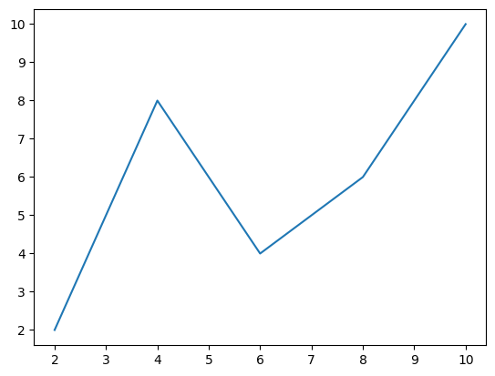

```python
import matplotlib.pyplot as pt
import numpy as np
x = np.array([2,4,6,8,10])
y = np.array([2,8,4,6,10])
pt.plot(x,y)
pt.show()
```

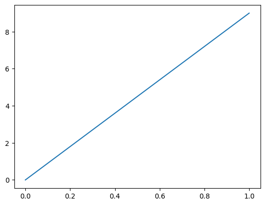

```python
import matplotlib.pyplot as pt
import numpy as np
x = np.array([0,1])
y = np.array([0,9])
pt.plot(x,y)
pt.show()
```

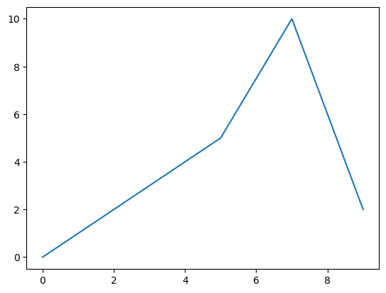

```python
import matplotlib.pyplot as pt
import numpy as np
x = np.array([0,3,5,7,9])
y = np.array([0,3,5,10,2])
pt.plot(x,y)
pt.show()
```

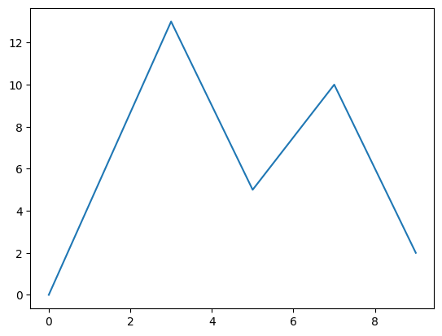

```python
import matplotlib.pyplot as pt
import numpy as np
x = np.array([0,3,5,7,9])
y = np.array([0,13,5,10,2])
pt.plot(x,y)
pt.show()
```

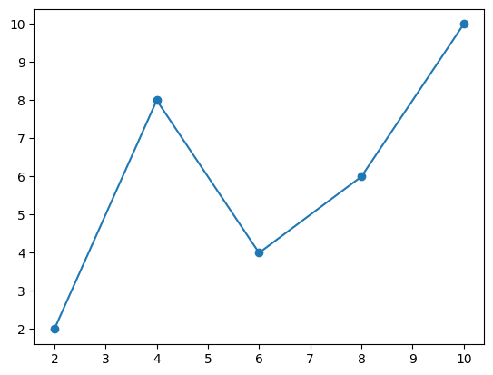

```python
import matplotlib.pyplot as pt
import numpy as np
x = np.array([2,4,6,8,10])
y = np.array([2,8,4,6,10])
pt.plot(x,y,marker='o')
pt.show()
```

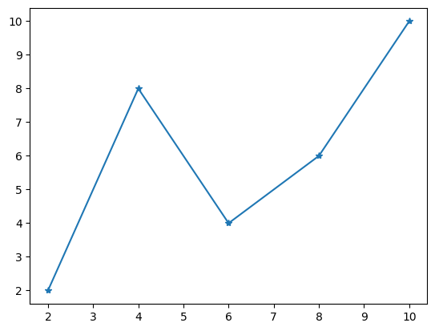

```python
import matplotlib.pyplot as pt
import numpy as np
x = np.array([2,4,6,8,10])
y = np.array([2,8,4,6,10])
pt.plot(x,y,marker='*')
pt.show()
```

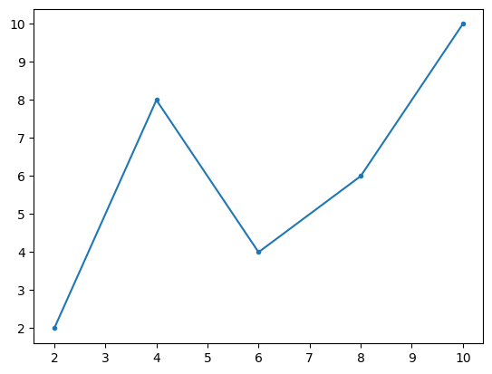

```python
import matplotlib.pyplot as pt
import numpy as np
x = np.array([2,4,6,8,10])
y = np.array([2,8,4,6,10])
pt.plot(x,y,marker='.')
pt.show()
```

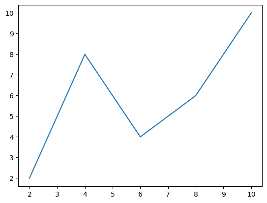

```python
import matplotlib.pyplot as pt
import numpy as np
x = np.array([2,4,6,8,10])
y = np.array([2,8,4,6,10])
pt.plot(x,y,marker=',')
pt.show()
```

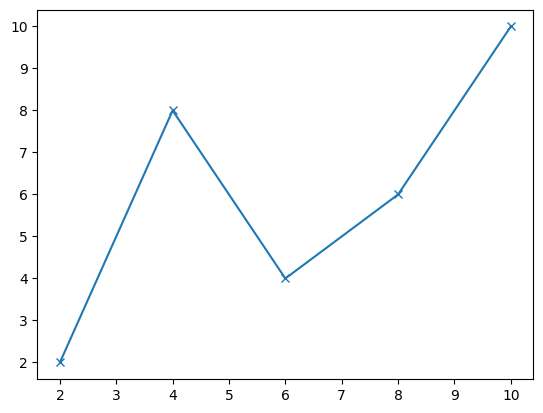

```python
import matplotlib.pyplot as pt
import numpy as np
x = np.array([2,4,6,8,10])
y = np.array([2,8,4,6,10])
pt.plot(x,y,marker='x')
pt.show()
```

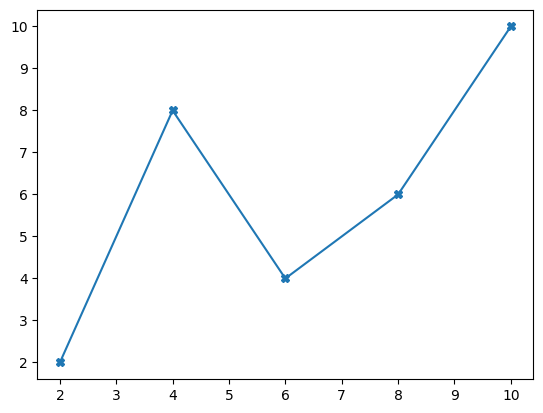

```python
import matplotlib.pyplot as pt
import numpy as np
x = np.array([2,4,6,8,10])
y = np.array([2,8,4,6,10])
pt.plot(x,y,marker='X')
pt.show()
```

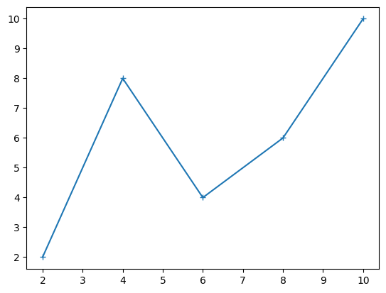

```python
import matplotlib.pyplot as pt
import numpy as np
x = np.array([2,4,6,8,10])
y = np.array([2,8,4,6,10])
pt.plot(x,y,marker='+')
pt.show()
```

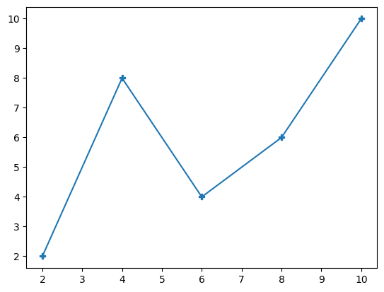

```python
import matplotlib.pyplot as pt
import numpy as np
x = np.array([2,4,6,8,10])
y = np.array([2,8,4,6,10])
pt.plot(x,y,marker='P')
pt.show()
```

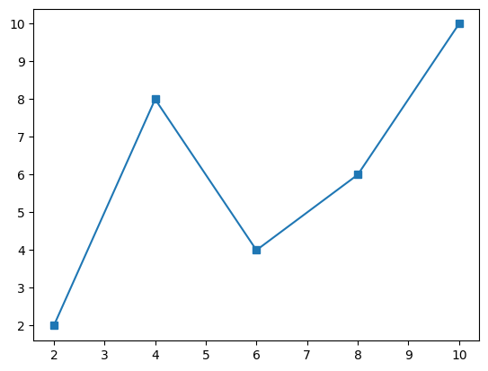

```python
import matplotlib.pyplot as pt
import numpy as np
x = np.array([2,4,6,8,10])
y = np.array([2,8,4,6,10])
pt.plot(x,y,marker='s')
pt.show()
```

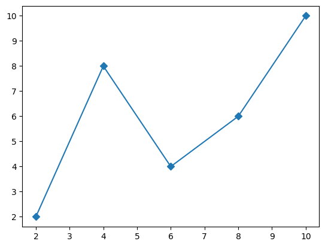

```python
import matplotlib.pyplot as pt
import numpy as np
x = np.array([2,4,6,8,10])
y = np.array([2,8,4,6,10])
pt.plot(x,y,marker='D')
pt.show()
```

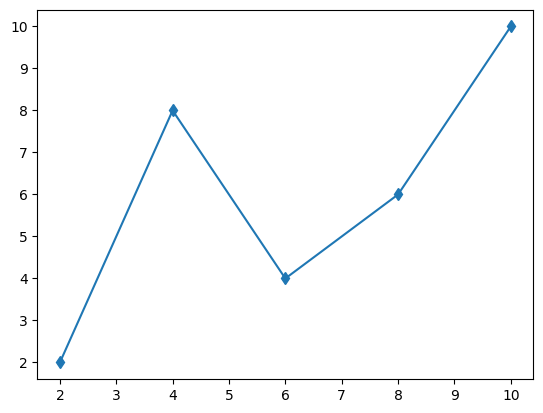

```python
import matplotlib.pyplot as pt
import numpy as np
x = np.array([2,4,6,8,10])
y = np.array([2,8,4,6,10])
pt.plot(x,y,marker='d')
pt.show()
```

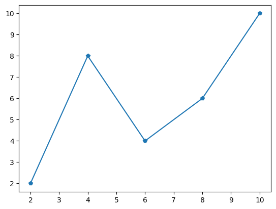

```python
import matplotlib.pyplot as pt
import numpy as np
x = np.array([2,4,6,8,10])
y = np.array([2,8,4,6,10])
pt.plot(x,y,marker='p')
pt.show()
```

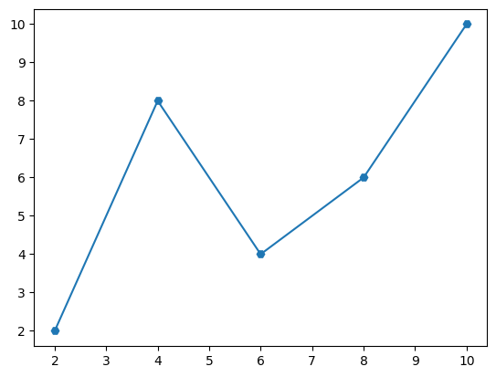

```python
import matplotlib.pyplot as pt
import numpy as np
x = np.array([2,4,6,8,10])
y = np.array([2,8,4,6,10])
pt.plot(x,y,marker='H')
pt.show()
```

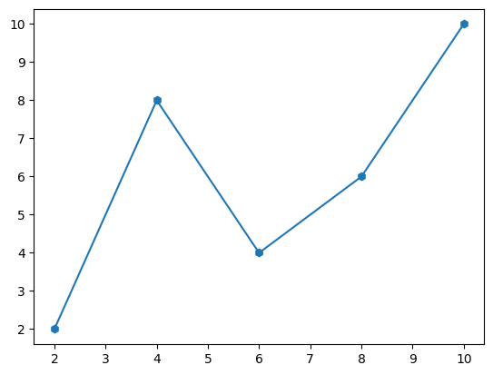

```python
import matplotlib.pyplot as pt
import numpy as np
x = np.array([2,4,6,8,10])
y = np.array([2,8,4,6,10])
pt.plot(x,y,marker='h')
pt.show()
```

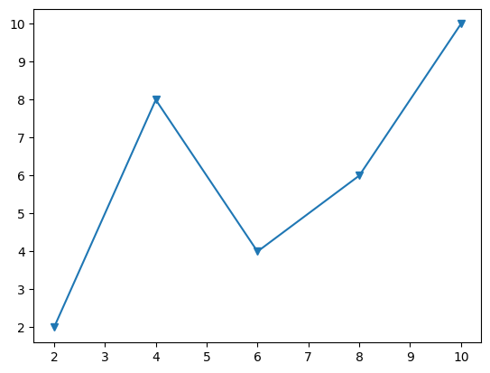

```python
import matplotlib.pyplot as pt
import numpy as np
x = np.array([2,4,6,8,10])
y = np.array([2,8,4,6,10])
pt.plot(x,y,marker='v')
pt.show()
```

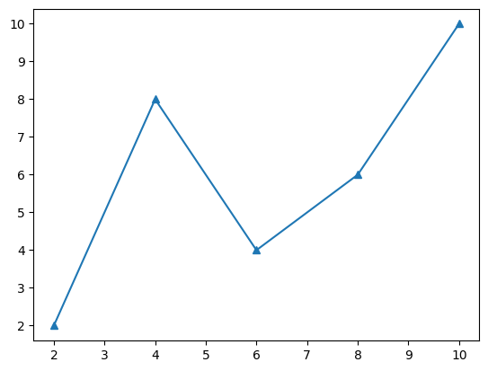

```python
import matplotlib.pyplot as pt
import numpy as np
x = np.array([2,4,6,8,10])
y = np.array([2,8,4,6,10])
pt.plot(x,y,marker='^')
pt.show()
```

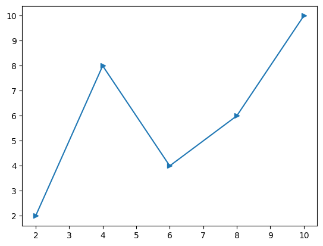

```python
import matplotlib.pyplot as pt
import numpy as np
x = np.array([2,4,6,8,10])
y = np.array([2,8,4,6,10])
pt.plot(x,y,marker='>')
pt.show()
```

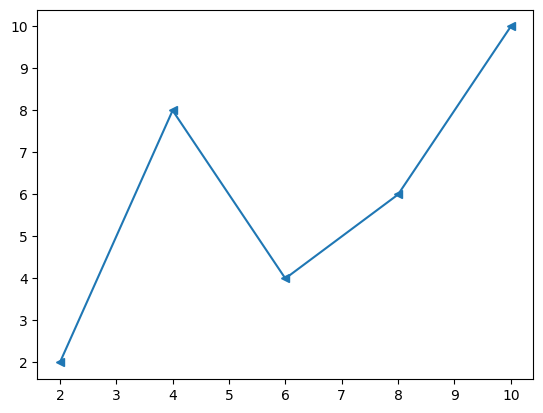

```python
import matplotlib.pyplot as pt
import numpy as np
x = np.array([2,4,6,8,10])
y = np.array([2,8,4,6,10])
pt.plot(x,y,marker='<')
pt.show()
```

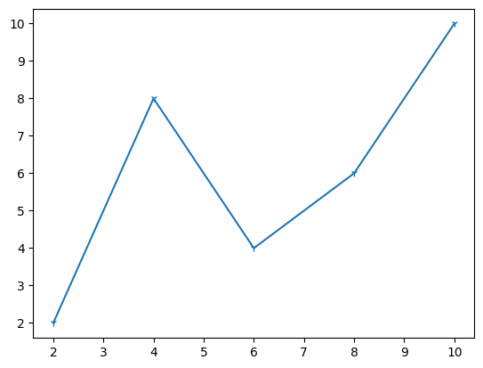

```python
import matplotlib.pyplot as pt
import numpy as np
x = np.array([2,4,6,8,10])
y = np.array([2,8,4,6,10])
pt.plot(x,y,marker='1')
pt.show()
```

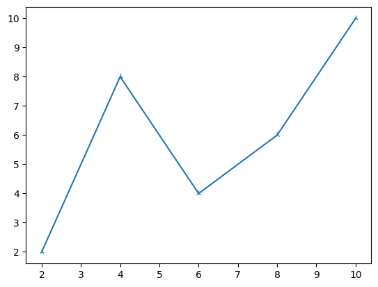

```python
import matplotlib.pyplot as pt
import numpy as np
x = np.array([2,4,6,8,10])
y = np.array([2,8,4,6,10])
pt.plot(x,y,marker='2')
pt.show()
```

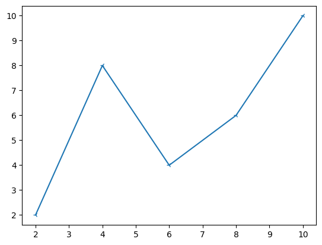

```python
import matplotlib.pyplot as pt
import numpy as np
x = np.array([2,4,6,8,10])
y = np.array([2,8,4,6,10])
pt.plot(x,y,marker='3')
pt.show()
```

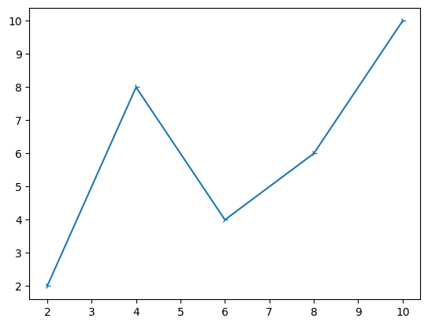

```python
import matplotlib.pyplot as pt
import numpy as np
x = np.array([2,4,6,8,10])
y = np.array([2,8,4,6,10])
pt.plot(x,y,marker='4')
pt.show()
```

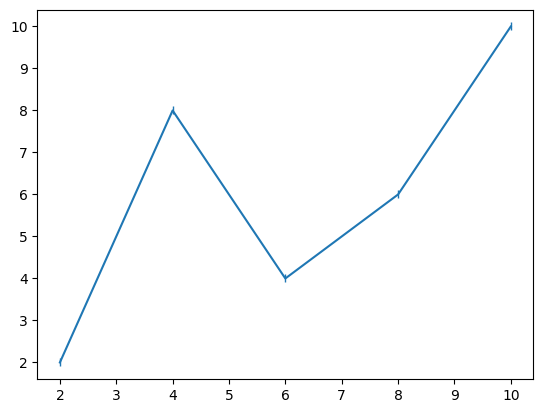

```python
import matplotlib.pyplot as pt
import numpy as np
x = np.array([2,4,6,8,10])
y = np.array([2,8,4,6,10])
pt.plot(x,y,marker='|')
pt.show()
```

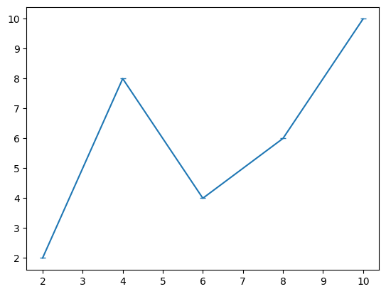

```python
import matplotlib.pyplot as pt
import numpy as np
x = np.array([2,4,6,8,10])
y = np.array([2,8,4,6,10])
pt.plot(x,y,marker='_')
pt.show()
```

- `Default x axis: When only 1 point of a single axis are given then Default values of x-axis are taken.`
- `Default y axis is not possible.`

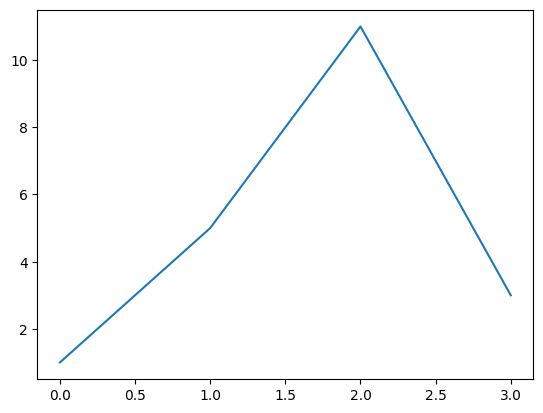

```python
import matplotlib.pyplot as pt
import numpy as np
x = np.array([1,5,11,3])
pt.plot(x)
pt.show()
```

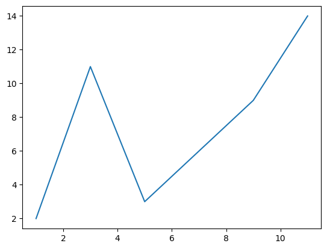

```python
import matplotlib.pyplot as pt
import numpy as np
x = np.array([1,3,5,9,11])
y = np.array([2,11,3,9,14])
pt.plot(x,y)
pt.show()
```

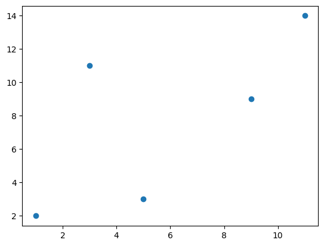

```python
import matplotlib.pyplot as pt
import numpy as np
x = np.array([1,3,5,9,11])
y = np.array([2,11,3,9,14])
pt.plot(x,y,'o')
pt.show()
```

- `Color:`

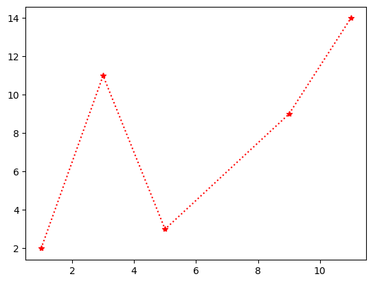

```python
import matplotlib.pyplot as pt
import numpy as np
x = np.array([1,3,5,9,11])
y = np.array([2,11,3,9,14])
pt.plot(x,y,'*:r')
pt.show()
```